# ECO4422_Project

Katelyn McCullough

2026-11-08

# 1. Research Environment and Setup

## 1.1 Required R Libraries

```r
library(haven)
library(dplyr)
library(stringr)
library(ggplot2)
library(tidyr)
library(knitr)
library(stringdist)
library(sandwich)
library(lmtest)
library(MatchIt)
library(cobalt)
library(broom)
```

The analysis was conducted in R using packages for data manipulation, visualization, statistical modeling, and causal inference. The `haven`, `dplyr`, `tidyr`, and `stringr` packages support data import, cleaning, and organization, while `ggplot2` and `knitr` are used to generate figures and tables. The `sandwich` and `lmtest` packages support regression diagnostics and robust standard errors. Finally, `MatchIt` and `cobalt` are used to implement matching and evaluate covariate balance, while `broom` assists with organizing model outputs.

## 1.2 Output Directories and Reproducibility

```r
dir.create("outputs", showWarnings = FALSE)
dir.create("outputs/tables", showWarnings = FALSE)
dir.create("outputs/figures", showWarnings = FALSE)
dir.create("outputs/data", showWarnings = FALSE)
dir.create("outputs/models", showWarnings = FALSE)

set.seed(4422)

getwd()
```

```
[1] "/Users/katelynmccullough/Library/CloudStorage/OneDrive-FloridaPolytechnicUniversity/Florida Polytechnic University/Econometrics/ECO4422_Project"
```

The project was configured to store generated tables, figures, processed datasets, and statistical models in separate directories to maintain an organized and reproducible workflow. A random seed of 4422 was established to support reproducibility in subsequent statistical analyses. The working directory was also verified to ensure that outputs are saved within the intended econometrics project folder.

# 2. Data Collection and Preparation

## 2.1 Importing the BAAD and NAG Datasets

```r
BAAD_raw <- read_sav(
  "/Users/katelynmccullough/Library/CloudStorage/OneDrive-FloridaPolytechnicUniversity/Florida Polytechnic University/Econometrics/ECO4422_Project/BAAD_Files/BAAD_Database.sav"
)

active_raw <- read.csv("~/Downloads/Monadic_Rebel_Group_active_support.csv", sep = ";")
passive_raw <- read.csv("~/Downloads/Monadic_Rebel_Group_defacto_support.csv", sep = ";")

# Check imported dimensions
dim(BAAD_raw)
```

```
[1] 395  19
```

```r
dim(active_raw)
```

```
[1] 6910   15
```

```r
dim(passive_raw)
```

```
[1] 6910   14
```

```r
# Inspect variable names
names(BAAD_raw)
```

```
 [1] "mastertccode3606"   "group"              "statespond"         "cowmastercountry"
 [5] "masterccode"        "fatalities19982005" "OrgAge"             "ordsize"
 [9] "terrStrong"         "degree"             "ContainRelig"       "ContainEthno"
[13] "LeftNoReligEthno"   "PureRelig"          "PureEthno"          "ReligEthno"
[17] "ContainRelig2"      "ContainEthno2"      "Islam"
```

```r
names(active_raw)
```

```
 [1] "Nag_Name"        "NagCode_1"       "NagCode_2"       "Year"            "NumNAG_S"
 [6] "Num_S_SafeMem"   "Num_S_SafeLead"  "Num_S_HeadQuar"  "Num_S_TrainCamp" "Num_S_Training"
[11] "Num_S_WeaponLog" "Num_S_FinAid"    "Num_S_Transport" "Num_S_Troop"     "Num_S_Other"
```

```r
names(passive_raw)
```

```
 [1] "Nag_Name"         "NagCode_1"        "NagCode_2"        "Year"             "NumNAG_DS"
 [6] "Num_DS_SafeMem"   "Num_DS_SafeLead"  "Num_DS_HeadQuar"  "Num_DS_TrainCamp" "Num_DS_Training"
[11] "Num_DS_WeaponLog" "Num_DS_FinAid"    "Num_DS_Transport" "Num_DS_Other"
```

Three datasets were imported for the analysis. The Big Allied and Dangerous (BAAD) dataset contains 395 terrorist organizations and 19 variables, including state sponsorship, organizational characteristics, and recorded fatalities from 1998 to 2005. Two supplementary Non-State Armed Groups (NAG) datasets were imported to examine active and de facto forms of state support. Each contains 6,910 observations, with 15 variables describing active support and 14 describing de facto support. The dimensions and variable names were inspected to confirm successful import and identify the variables required for subsequent data processing and merging.

## 2.2 Data Validation and Integrity Checks

```r
# Required BAAD variables

baad_required <- c(
  "mastertccode3606",
  "group",
  "statespond",
  "fatalities19982005",
  "OrgAge",
  "ordsize",
  "terrStrong",
  "degree",
  "ContainRelig",
  "ContainEthno"
)

missing_baad <- setdiff(
  baad_required,
  names(BAAD_raw)
)

if (length(missing_baad) > 0) {
  stop(
    "Missing BAAD variables: ",
    paste(missing_baad, collapse = ", ")
  )
}

# Required NAG variables

active_required <- c(
  "NagCode_1",
  "NagCode_2",
  "Nag_Name",
  "Year",
  "NumNAG_S"
)

passive_required <- c(
  "NagCode_1",
  "NagCode_2",
  "Nag_Name",
  "Year",
  "NumNAG_DS"
)

stopifnot(
  all(active_required %in% names(active_raw)),
  all(passive_required %in% names(passive_raw))
)

# Verify organization-level uniqueness
baad_duplicates <- BAAD_raw %>%
  count(mastertccode3606) %>%
  filter(n > 1)

print(baad_duplicates)
```

```
# A tibble: 0 × 2
# ℹ 2 variables: mastertccode3606 <dbl>, n <int>
```

```r
if (nrow(baad_duplicates) > 0) {
  stop("Duplicate BAAD organization IDs detected.")
}

# Sponsorship and fatality validation
stopifnot(
  all(
    na.omit(as.numeric(BAAD_raw$statespond)) %in%
      c(0, 1)
  ),
  all(
    na.omit(
      as.numeric(BAAD_raw$fatalities19982005)
    ) >= 0
  )
)

# Check missing values in primary variables

BAAD_raw %>%
  summarise(
    missing_sponsorship = sum(is.na(statespond)),
    missing_fatalities = sum(is.na(fatalities19982005)),
    missing_organization_ids = sum(is.na(mastertccode3606))
  )
```

| missing_sponsorship | missing_fatalities | missing_organization_ids |
| --- | --- | --- |
| 0 | 0 | 0 |

Data integrity checks were conducted before merging and analyzing the datasets. All required variables were present in their respective datasets, and no duplicate organization identifiers were detected in BAAD, confirming that each organization has a unique recorded identifier. State sponsorship values were verified to follow the expected binary coding, and fatality counts were confirmed to be nonnegative. These checks establish that the imported data meet the basic structural and coding requirements for subsequent analysis, although they do not independently establish the accuracy of the original measurements.

## 2.3 Restricting the NAG Data to the Study Period

```r
# Restrict NAG observations to 1998–2005

active <- active_raw %>%
  filter(between(Year, 1998, 2005))

passive <- passive_raw %>%
  filter(between(Year, 1998, 2005))

dim(active)
```

```
[1] 883  15
```

```r
dim(passive)
```

```
[1] 883  14
```

Both NAG datasets were restricted to observations recorded between 1998 and 2005 to align with the BAAD study period. Following this restriction, the active and de facto support datasets each contained 883 observations, retaining 15 and 14 variables, respectively. This ensures that subsequent measures of state support are constructed using records from the same eight-year period as the organizational fatality outcome.

## 2.4 Verifying Unique Organization-Year Records

```r
# Each organization-code combination should have
# at most one observation per year.

nag_keys <- c(
  "NagCode_1",
  "NagCode_2",
  "Year"
)

active_duplicates <- active %>%
  count(across(all_of(nag_keys))) %>%
  filter(n > 1)

passive_duplicates <- passive %>%
  count(across(all_of(nag_keys))) %>%
  filter(n > 1)

print(active_duplicates)
```

```
[1] NagCode_1 NagCode_2 Year      n
<0 rows> (or 0-length row.names)
```

```r
print(passive_duplicates)
```

```
[1] NagCode_1 NagCode_2 Year      n
<0 rows> (or 0-length row.names)
```

```r
if (
  nrow(active_duplicates) > 0 ||
  nrow(passive_duplicates) > 0
) {
  stop(
    "Duplicate NAG year keys detected. ",
    "Review the unit of observation before joining."
  )
}
```

The active and de facto support datasets were examined for duplicate records using the combination of `NagCode_1`, `NagCode_2`, and `Year` as a unique identifier. Neither dataset contained duplicate combinations of these variables, indicating that each organization-code combination appears at most once per year. This confirms that the selected keys are unique within each dataset and can be used to merge the two sources without introducing duplicate observations through repeated keys.

## 2.5 Merging Active and De Facto State Support Records

```r
# Preserve organization names from either source

support <- active %>%
  rename(Nag_Name_active = Nag_Name) %>%
  full_join(
    passive %>%
      rename(Nag_Name_passive = Nag_Name),
    by = nag_keys,
    suffix = c("_active", "_passive")
  ) %>%
  mutate(
    Nag_Name = coalesce(
      Nag_Name_active,
      Nag_Name_passive
    )
  )

# Verify complete overlap between the two datasets

active_only_records <- anti_join(
  active,
  passive,
  by = nag_keys
)

passive_only_records <- anti_join(
  passive,
  active,
  by = nag_keys
)

cat(
  "Active-only records:", nrow(active_only_records), "\n",
  "De facto-only records:", nrow(passive_only_records), "\n"
)
```

```
Active-only records: 0
 De facto-only records: 0
```

```r
dim(support)
```

```
[1] 883  27
```

```r
names(support)
```

```
 [1] "Nag_Name_active"  "NagCode_1"        "NagCode_2"        "Year"             "NumNAG_S"
 [6] "Num_S_SafeMem"    "Num_S_SafeLead"   "Num_S_HeadQuar"   "Num_S_TrainCamp"  "Num_S_Training"
[11] "Num_S_WeaponLog"  "Num_S_FinAid"     "Num_S_Transport"  "Num_S_Troop"      "Num_S_Other"
[16] "Nag_Name_passive" "NumNAG_DS"        "Num_DS_SafeMem"   "Num_DS_SafeLead"  "Num_DS_HeadQuar"
[21] "Num_DS_TrainCamp" "Num_DS_Training"  "Num_DS_WeaponLog" "Num_DS_FinAid"    "Num_DS_Transport"
[26] "Num_DS_Other"     "Nag_Name"
```

The active and de facto state support datasets were merged using the organization identifiers `NagCode_1` and `NagCode_2` together with the observation year. A full join was used to preserve records appearing in either dataset, and organization names were consolidated into a common variable while retaining the original source-specific names. The resulting dataset contains 883 observations and 27 variables, combining information on both forms of state support for the 1998–2005 study period. The unchanged observation count is consistent with complete overlap between the two datasets, subject to verification of their joining keys.

## 2.6 Classifying Active and De Facto State Support

```r
# Keep missing support values distinct from zero

support <- support %>%
  mutate(
    active_recorded = case_when(
      is.na(NumNAG_S) ~ NA_integer_,
      NumNAG_S > 0 ~ 1L,
      TRUE ~ 0L
    ),
    passive_recorded = case_when(
      is.na(NumNAG_DS) ~ NA_integer_,
      NumNAG_DS > 0 ~ 1L,
      TRUE ~ 0L
    )
  )

support %>%
  count(
    active_recorded,
    passive_recorded,
    name = "observations"
  )
```

| active_recorded | passive_recorded | observations |
| --- | --- | --- |
| 0 | 0 | 206 |
| 0 | 1 | 194 |
| 1 | 0 | 185 |
| 1 | 1 | 298 |

```r
# Inspect observations with both types of support

support %>%
  filter(
    active_recorded == 1,
    passive_recorded == 1
  ) %>%
  select(
    Nag_Name,
    Year,
    NumNAG_S,
    NumNAG_DS,
    any_of(c(
      "Num_S_FinAid",
      "Num_DS_FinAid",
      "Num_S_WeaponLog",
      "Num_DS_WeaponLog"
    ))
  ) %>%
  as_tibble() %>%
  print(n = 10)
```

```
# A tibble: 298 × 8
   Nag_Name     Year NumNAG_S NumNAG_DS Num_S_FinAid Num_DS_FinAid Num_S_WeaponLog Num_DS_WeaponLog
   <chr>       <int>    <int>     <int>        <int>         <int>           <int>            <int>
 1 al-Gama'a …  1998        2         1            0             1               1                0
 2 Al-Itihaad…  1998        5        12            3             7               3                5
 3 Al-Itihaad…  1999        5        12            3             7               3                5
 4 Al-Mahdi A…  2003        1         2            1             1               1                1
 5 Al-Mahdi A…  2004        1         2            1             1               1                1
 6 Al-Mahdi A…  2005        1         2            1             1               1                1
 7 al-Qaida     1998        2         9            0             6               0                1
 8 al-Qaida     1999        2         9            0             6               0                1
 9 al-Qaida     2000        2         9            0             6               0                1
10 al-Qaida     2001        2        10            0             7               0                1
# ℹ 288 more rows
# ℹ Use `print(n = ...)` to see more rows
```

Binary indicators were constructed to identify whether each organization received active or de facto state support during a given year, while preserving missing observations separately from recorded zeros. Of the 883 organization-year records, 298 (33.7%) exhibited both types of support, 185 (21.0%) recorded active support only, and 194 (22.0%) recorded de facto support only. The remaining 206 observations (23.3%) recorded neither type. Additional inspection of organizations receiving both forms of support provided information on specific assistance categories, including financial aid and weapons logistics. These classifications establish the basis for examining patterns of state assistance over the study period.

## 2.7 Aggregating State Support to the Organization Level

```r
# Aggregate NAG observations across 1998–2005

support_summary <- support %>%
  group_by(
    NagCode_1,
    NagCode_2
  ) %>%
  summarise(
    Nag_Name = first(
      Nag_Name[!is.na(Nag_Name)],
      default = NA_character_
    ),

    years_observed = n_distinct(Year),

    years_active_observed = sum(
      !is.na(active_recorded)
    ),

    years_passive_observed = sum(
      !is.na(passive_recorded)
    ),

    years_active = sum(
      active_recorded == 1,
      na.rm = TRUE
    ),

    years_passive = sum(
      passive_recorded == 1,
      na.rm = TRUE
    ),

    any_active = as.integer(
      years_active > 0
    ),

    any_passive = as.integer(
      years_passive > 0
    ),

    .groups = "drop"
  ) %>%
  mutate(
    support_type = case_when(
      any_active == 1 & any_passive == 1 ~ "Both",
      any_active == 1 ~ "Active only",
      any_passive == 1 ~ "Passive only",
      years_active_observed > 0 &
        years_passive_observed > 0 ~ "Neither recorded",
      TRUE ~ "Incomplete support information"
    )
  )

# Support categories
support_summary %>%
  count(support_type)
```

| support_type | n |
| --- | --- |
| Active only | 30 |
| Both | 62 |
| Neither recorded | 36 |
| Passive only | 32 |

```r
# Save NAG summary
write.csv(
  support_summary,
  "outputs/data/nag_support_summary.csv",
  row.names = FALSE
)
```

Annual state support observations were aggregated into organization-level records covering the 1998–2005 study period. The aggregation measured the number of observed years, the number of years with active or de facto support, and whether each support type occurred at least once. The initial classification identified 160 organization-code combinations, including 62 (38.75%) receiving both forms of support, 30 (18.75%) receiving active support only, 32 (20.00%) receiving de facto support only, and 36 (22.50%) with neither form recorded. These organization-level measures were exported for subsequent matching with the BAAD dataset. The final category counts should be confirmed after applying the revised missing-data classification.

## 2.8 Standardizing Organization Names for Dataset Matching

```r
# Standardize names for exact string matching

clean_group_name <- function(x) {
  x %>%
    str_to_lower() %>%
    str_remove_all("\\([^)]*\\)") %>%
    str_replace_all("[^a-z0-9]", "") %>%
    str_trim()
}

support_summary <- support_summary %>%
  mutate(
    match_name = clean_group_name(Nag_Name)
  )

BAAD <- BAAD_raw %>%
  mutate(
    match_name = clean_group_name(group)
  )

# Check for ambiguous standardized NAG names

ambiguous_names <- support_summary %>%
  filter(
    !is.na(match_name),
    match_name != ""
  ) %>%
  count(match_name) %>%
  filter(n > 1)

print(ambiguous_names)
```

```
# A tibble: 6 × 2
  match_name                                  n
  <chr>                                   <int>
1 alqaedaintheislamicmaghreb                  2
2 islamicmovementofuzbekistan                 2
3 kosovaliberationarmy                        2
4 militaryfaction                             2
5 nationalcouncilforthedefenseofdemocracy     2
6 sudanliberationmovementarmy                 2
```

```r
# Inspect ambiguous standardized organization names

ambiguous_details <- support_summary %>%
  semi_join(
    ambiguous_names,
    by = "match_name"
  ) %>%
  select(
    match_name,
    Nag_Name,
    NagCode_1,
    NagCode_2
  ) %>%
  arrange(match_name, NagCode_1, NagCode_2)

print(ambiguous_details, n = Inf, width = Inf)
```

```
# A tibble: 12 × 4
   match_name                              Nag_Name                                      NagCode_1
   <chr>                                   <chr>                                             <int>
 1 alqaedaintheislamicmaghreb              Al-Qaeda in the Islamic Maghreb                     351
 2 alqaedaintheislamicmaghreb              Al-Qaeda in the Islamic Maghreb (AQIM)              482
 3 islamicmovementofuzbekistan             Islamic Movement of Uzbekistan                      199
 4 islamicmovementofuzbekistan             Islamic Movement of Uzbekistan (IMU)                485
 5 kosovaliberationarmy                    Kosova Liberation Army (UCK)                        197
 6 kosovaliberationarmy                    Kosova Liberation Army                              201
 7 militaryfaction                         Military faction                                    362
 8 militaryfaction                         Military faction (forces of André Kolingba)         364
 9 nationalcouncilforthedefenseofdemocracy National Council for the Defense of Democracy       246
10 nationalcouncilforthedefenseofdemocracy National Council for the Defense of Democracy       555
11 sudanliberationmovementarmy             Sudan Liberation Movement/Army                      278
12 sudanliberationmovementarmy             Sudan Liberation Movement/Army                      281
   NagCode_2
       <int>
 1         0
 2         0
 3         0
 4         0
 5         0
 6         0
 7         0
 8         0
 9         0
10         0
11         0
12         0
```

Organization names were standardized across the BAAD and NAG datasets to facilitate record linkage despite differences in capitalization, punctuation, and abbreviated names. The standardization procedure converted names to lowercase and removed parenthetical text and nonalphanumeric characters. A diagnostic check identified six standardized names associated with multiple NAG organization-code combinations, indicating potential ambiguity in name-based matching. These cases require additional verification to avoid incorrectly linking distinct organizations or organizational factions during the subsequent merge.

## 2.9 Identifying State-Sponsored Organizations in BAAD

```r
BAAD_sponsored <- BAAD %>%
  filter(statespond == 1)

# Count sponsored organizations
nrow(BAAD_sponsored)
```

```
[1] 32
```

```r
# Count nonsponsored organizations
BAAD %>%
  count(statespond)
```

| statespond | n |
| --- | --- |
| 0 | 363 |
| 1 | 32 |

The BAAD dataset was divided according to the binary state sponsorship indicator to establish the treatment and comparison groups for subsequent analysis. Of the 395 terrorist organizations, 32 (8.10%) were classified as state-sponsored, while 363 (91.90%) were classified as nonsponsored. The sponsored organizations were isolated for subsequent linkage with the NAG support records. The relatively small sponsored group highlights the imbalance in treatment-group sizes and motivates the use of matching methods to construct more comparable treatment and control samples.

## 2.10 Identifying Exact Organization-Name Matches

```r
# Exact normalized-name matches

matched_sponsored <- BAAD_sponsored %>%
  inner_join(
    support_summary,
    by = "match_name",
    relationship = "many-to-many"
  )

# Inspect matched organizations
matched_sponsored %>%
  select(
    mastertccode3606,
    group,
    Nag_Name,
    NagCode_1,
    NagCode_2,
    fatalities19982005,
    support_type,
    years_active,
    years_passive
  ) %>%
  print(n = Inf, width = Inf)
```

```
# A tibble: 11 × 9
   mastertccode3606 group
              <dbl> <chr>
 1             9896 Revolutionary United Front (RUF)
 2              304 Movement for Democracy and Justice in Chad (MDJT)
 3              262 Kurdistan Workers' Party (PKK)
 4               19 al-Gama'a al-Islamiyya (GAI)
 5              207 Hezbollah
 6             9819 Palestinian Islamic Jihad (PIJ)
 7             9836 Popular Front for the Liberation of Palestine (PFLP)
 8            10079 National Socialist Council of Nagaland-Isak-Muivah (NSCN-IM)
 9             9975 United Liberation Front of Assam (ULFA)
10              276 Liberation Tigers of Tamil Eelam (LTTE)
11            10169 Free Papua Movement (OPM)
   Nag_Name                                           NagCode_1 NagCode_2 fatalities19982005
```

[output cut: 25 more lines]

```r
# Count unique BAAD organizations matched
n_distinct(matched_sponsored$mastertccode3606)
```

```
[1] 11
```

An initial record-linkage procedure was conducted by joining state-sponsored BAAD organizations to NAG records using standardized organization names. This procedure identified 11 unique matches among the 32 sponsored BAAD organizations, representing 34.38% of the sponsored sample. The matched records include organizational fatality counts, active and de facto support classifications, and the number of years each support type was observed. The remaining 21 sponsored organizations were not matched through the initial name-standardization procedure and require further investigation of alternative names, abbreviations, or organizational identities.

## 2.11 Identifying Unmatched State-Sponsored Organizations

```r
unmatched_sponsored <- BAAD_sponsored %>%
  anti_join(
    support_summary %>%
      filter(
        !is.na(match_name),
        match_name != ""
      ) %>%
      distinct(match_name),
    by = "match_name"
  ) %>%
  select(
    mastertccode3606,
    group,
    cowmastercountry,
    fatalities19982005
  )

print(
  unmatched_sponsored,
  n = Inf,
  width = Inf
)
```

```
# A tibble: 21 × 4
   mastertccode3606 group                                                   cowmastercountry
              <dbl> <chr>                                                   <chr>
 1              317 National Liberation Army (Colombia)                     Colombia
 2              306 Movement of the Revolutionary Left                      Chile
 3              278 Lord's Resistance Army (LRA)                            Uganda
 4            20026 Eritrean Islamic Jihad Movement (EIJM)                  Eritrea
 5             9904 Salafist Group for Call and Combat (GSPC)               Algeria
 6             9825 People's Liberation Army of Kurdistan (ARGK)            Turkey
 7              282 Mahdi Army                                              Iraq
 8               39 Amal                                                    Lebanon
 9            30038 Strugglers for the Unity and Freedom of Greater Syria   Lebanon
10              147 Democratic Front for the Liberation of Palestine (DFLP) Israel
11              200 Hamas                                                   Israel
12               17 al-Fatah                                                Israel
```

[output cut: 32 more lines]

```r
nrow(unmatched_sponsored)
```

```
[1] 21
```

Following the initial standardized-name matching procedure, an anti-join was used to identify state-sponsored BAAD organizations without corresponding NAG records. This identified 21 unmatched organizations, representing 65.62% of the 32 sponsored organizations in BAAD. The unmatched records were retained with their organizational identifiers, names, countries, and fatality counts to support further examination. Several organizations may be represented under alternative names or abbreviations in the NAG data, making additional name verification necessary before constructing the final merged dataset.

## 2.12 Constructing and Validating a Manual Organization Crosswalk

```r
crosswalk <- tibble(
  group = c(
    "National Liberation Army (Colombia)",
    "Lord's Resistance Army (LRA)",
    "Mahdi Army",
    "Taliban",
    "Hamas",
    "al-Fatah"
  ),
  Nag_Name = c(
    "The National Liberation Army (ELN)",
    "The Lord's Resistance Army",
    "Al-Mahdi Army",
    "Taleban",
    "Islamic Resistance Movement",
    "Fatah"
  )
)

crosswalk_check <- crosswalk %>%
  left_join(
    support_summary,
    by = "Nag_Name",
    relationship = "many-to-many"
  ) %>%
  select(
    group,
    Nag_Name,
    NagCode_1,
    NagCode_2,
    support_type,
    years_active,
    years_passive
  )

print(crosswalk_check, n = Inf)
```

```
# A tibble: 6 × 7
  group                        Nag_Name NagCode_1 NagCode_2 support_type years_active years_passive
  <chr>                        <chr>        <int>     <int> <chr>               <int>         <int>
1 National Liberation Army (C… The Nat…       408         0 Both                    8             5
2 Lord's Resistance Army (LRA) The Lor…       300         0 Both                    8             4
3 Mahdi Army                   Al-Mahd…        73         0 Both                    3             3
4 Taliban                      Taleban        143         0 Both                    8             8
5 Hamas                        Islamic…        50         0 Both                    8             8
6 al-Fatah                     Fatah           48         0 Passive only            0             8
```

```r
# Which proposed names were not found?
crosswalk_check %>%
  filter(is.na(NagCode_1))
```

| group | Nag_Name | NagCode_1 | NagCode_2 | support_type | years_active | years_passive |
| --- | --- | --- | --- | --- | --- | --- |

A manual organization-name crosswalk was constructed to identify potential matches that were not captured by the initial standardized-name procedure. Six BAAD organizations were associated with alternative names recorded in the NAG dataset, including differences in spelling, abbreviations, and organizational naming conventions. All six proposed NAG names were located successfully, and the resulting records provided corresponding organization codes and state support classifications. These candidate links expand the potential coverage of the BAAD–NAG merge, although organizational identity must be verified before the mappings are incorporated into the final analytical dataset.

## 2.13 Evaluating Additional Candidate Organization Matches

```r
candidate_matches <- tibble::tribble(
  ~group, ~NagCode_1, ~match_status,

  "National Liberation Army (Colombia)",
  408, "Alias",

  "Lord's Resistance Army (LRA)",
  300, "Alias",

  "Mahdi Army",
  73, "Alias",

  "Taliban",
  143, "Alias",

  "Hamas",
  50, "Alias",

  "al-Fatah",
  48, "Alias",

  "Salafist Group for Call and Combat (GSPC)",
  351, "Historical name - coding review",

  "Eritrean Islamic Jihad Movement (EIJM)",
  307, "Possible subgroup",

  "Moro National Liberation Front (MNLF)",
  119, "Possible faction"
)

candidate_check <- candidate_matches %>%
  left_join(
    support_summary,
    by = "NagCode_1",
    relationship = "many-to-many"
  ) %>%
  select(
    group,
    Nag_Name,
    NagCode_1,
    NagCode_2,
    match_status,
    years_observed,
    years_active,
    years_passive
  )

print(candidate_check, n = Inf, width = Inf)
```

```
# A tibble: 9 × 8
  group
  <chr>
1 National Liberation Army (Colombia)
2 Lord's Resistance Army (LRA)
3 Mahdi Army
4 Taliban
5 Hamas
6 al-Fatah
7 Salafist Group for Call and Combat (GSPC)
8 Eritrean Islamic Jihad Movement (EIJM)
9 Moro National Liberation Front (MNLF)
  Nag_Name                                                 NagCode_1 NagCode_2
  <chr>                                                        <dbl>     <int>
1 The National Liberation Army (ELN)                             408         0
```

[output cut: 19 more lines]

```r
# Investigate selected organization codes

support_summary %>%
  filter(NagCode_1 %in% c(351, 482)) %>%
  select(
    Nag_Name,
    NagCode_1,
    NagCode_2,
    years_observed,
    years_active,
    years_passive,
    support_type
  ) %>%
  print(n = Inf, width = Inf)
```

```
# A tibble: 2 × 7
  Nag_Name                               NagCode_1 NagCode_2 years_observed years_active
  <chr>                                      <int>     <int>          <int>        <int>
1 Al-Qaeda in the Islamic Maghreb              351         0              8            0
2 Al-Qaeda in the Islamic Maghreb (AQIM)       482         0              8            0
  years_passive support_type
          <int> <chr>
1             8 Passive only
2             0 Neither recorded
```

The manual matching procedure was expanded to examine nine candidate links between BAAD and NAG organizations. Six candidates were retained as previously identified aliases, while three additional cases were flagged for further investigation because of possible historical renaming, subgroup relationships, or organizational faction differences. Examination of the Al-Qaeda in the Islamic Maghreb records identified two distinct NAG organization codes with different recorded support classifications, illustrating the risk of assigning support information based on similar names alone. Consequently, the three uncertain candidates were retained for review but excluded from the verified matching procedure to reduce the risk of misclassification.

## 2.14 Consolidating and Validating BAAD–NAG Organization Matches

```r
# Exact matches with unique organization identifiers

exact_matches <- matched_sponsored %>%
  select(
    mastertccode3606,
    group,
    NagCode_1,
    NagCode_2
  ) %>%
  distinct() %>%
  mutate(match_method = "Exact name")

# Candidate aliases that were previously reviewed

alias_matches <- candidate_matches %>%
  filter(match_status == "Alias") %>%
  select(
    group,
    NagCode_1
  ) %>%
  left_join(
    BAAD %>%
      select(mastertccode3606, group),
    by = "group"
  ) %>%
  left_join(
    support_summary %>%
      select(
        NagCode_1,
        NagCode_2,
        Nag_Name
      ),
    by = "NagCode_1",
    relationship = "many-to-many"
  ) %>%
  mutate(match_method = "Manual alias")

# Inspect all candidate alias combinations

print(
  alias_matches,
  n = Inf,
  width = Inf
)
```

```
# A tibble: 6 × 6
  group                               NagCode_1 mastertccode3606 NagCode_2
  <chr>                                   <dbl>            <dbl>     <int>
1 National Liberation Army (Colombia)       408              317         0
2 Lord's Resistance Army (LRA)              300              278         0
3 Mahdi Army                                 73              282         0
4 Taliban                                   143             9940         0
5 Hamas                                      50              200         0
6 al-Fatah                                   48               17         0
  Nag_Name                           match_method
  <chr>                              <chr>
1 The National Liberation Army (ELN) Manual alias
2 The Lord's Resistance Army         Manual alias
3 Al-Mahdi Army                      Manual alias
4 Taleban                            Manual alias
5 Islamic Resistance Movement        Manual alias
6 Fatah                              Manual alias
```

```r
# Check for missing keys
unresolved_aliases <- alias_matches %>%
  filter(
    is.na(mastertccode3606) |
    is.na(NagCode_1) |
    is.na(NagCode_2)
  )

print(unresolved_aliases)
```

```
# A tibble: 0 × 6
# ℹ 6 variables: group <chr>, NagCode_1 <dbl>, mastertccode3606 <dbl>, NagCode_2 <int>,
#   Nag_Name <chr>, match_method <chr>
```

```r
# Combine exact and alias matches

verified_matches <- bind_rows(
  exact_matches,
  alias_matches %>%
    select(
      mastertccode3606,
      group,
      NagCode_1,
      NagCode_2,
      match_method
    )
) %>%
  filter(
    !is.na(mastertccode3606),
    !is.na(NagCode_1),
    !is.na(NagCode_2)
  ) %>%
  distinct()

# A BAAD organization must not map to
# multiple distinct NAG code combinations.

ambiguous_matches <- verified_matches %>%
  distinct(
    mastertccode3606,
    NagCode_1,
    NagCode_2
  ) %>%
  count(mastertccode3606) %>%
  filter(n > 1)

print(ambiguous_matches)
```

```
# A tibble: 0 × 2
# ℹ 2 variables: mastertccode3606 <dbl>, n <int>
```

```r
if (nrow(ambiguous_matches) > 0) {
  stop(
    "Ambiguous BAAD-to-NAG matches detected. ",
    "Review the crosswalk before continuing."
  )
}

# One verified record per BAAD organization

verified_matches <- verified_matches %>%
  arrange(
    mastertccode3606,
    desc(match_method == "Exact name")
  ) %>%
  distinct(mastertccode3606, .keep_all = TRUE)

nrow(verified_matches)
```

```
[1] 17
```

The standardized-name matches and manually identified aliases were consolidated into a single BAAD–NAG organization crosswalk. The procedure combined 11 initial name matches with six additional alias matches, producing 17 unique linked organizations, or 53.13% of the 32 state-sponsored organizations in BAAD. Validation checks found no missing organization identifiers or cases in which a BAAD organization was assigned multiple distinct NAG codes. The resulting crosswalk provides the basis for integrating additional state support information into BAAD, while the 15 remaining unmatched organizations are retained separately to avoid assigning unsupported organizational identities.

## 2.15 Assessing Final BAAD–NAG Matching Coverage

```r
# Organizations successfully linked to NAG

matched_groups <- verified_matches %>%
  pull(mastertccode3606)

# Sponsored organizations still unmatched

still_unmatched <- BAAD_sponsored %>%
  filter(
    !mastertccode3606 %in% matched_groups
  ) %>%
  select(
    mastertccode3606,
    group,
    cowmastercountry,
    fatalities19982005
  )

print(
  still_unmatched,
  n = Inf,
  width = Inf
)
```

```
# A tibble: 15 × 4
   mastertccode3606 group                                                   cowmastercountry
              <dbl> <chr>                                                   <chr>
 1              306 Movement of the Revolutionary Left                      Chile
 2            20026 Eritrean Islamic Jihad Movement (EIJM)                  Eritrea
 3             9904 Salafist Group for Call and Combat (GSPC)               Algeria
 4             9825 People's Liberation Army of Kurdistan (ARGK)            Turkey
 5               39 Amal                                                    Lebanon
 6            30038 Strugglers for the Unity and Freedom of Greater Syria   Lebanon
 7              147 Democratic Front for the Liberation of Palestine (DFLP) Israel
 8            20035 Islamic Defense Force                                   India
 9            30005 Jihad Committee                                         India
10             9934 Students Islamic Movement of India (SIMI)               India
11              205 Harakat ul-Mudjahidin (HuM)                             Pakistan
12              264 Lashkar-e-Jhangvi (LeJ)                                 Pakistan
```

[output cut: 20 more lines]

```r
# Match summary

match_summary <- tibble(
  total_sponsored = nrow(BAAD_sponsored),

  verified_matches = n_distinct(
    verified_matches$mastertccode3606
  ),

  still_unmatched = nrow(still_unmatched),

  match_rate = 100 *
    verified_matches /
    total_sponsored
)
```

Following the consolidation of standardized-name and manual alias matches, 15 of the 32 state-sponsored BAAD organizations remained unmatched to the NAG dataset. The combined matching procedure therefore linked 17 organizations, representing 53.13% of the sponsored sample. The remaining 15 organizations were retained for documentation rather than assigned uncertain NAG identities. This distinction is important because incomplete record linkage limits the coverage of supplementary active and de facto support classifications, although the unmatched organizations remain available for the primary BAAD-based analysis of state sponsorship and fatalities.

## 2.16 Exporting the Organization Matching Results

```r
match_summary <- tibble(
  total_sponsored = nrow(BAAD_sponsored),
  verified_matches = nrow(verified_matches),
  still_unmatched = nrow(still_unmatched)
) %>%
  mutate(
    match_rate = 100 *
      verified_matches / total_sponsored
  )

print(match_summary)
```

```
# A tibble: 1 × 4
  total_sponsored verified_matches still_unmatched match_rate
            <int>            <int>           <int>      <dbl>
1              32               17              15       53.1
```

```r
write.csv(
  match_summary,
  "outputs/tables/nag_match_summary.csv",
  row.names = FALSE
)

write.csv(
  still_unmatched,
  "outputs/tables/nag_unmatched_groups.csv",
  row.names = FALSE
)

write.csv(
  verified_matches,
  "outputs/data/verified_nag_crosswalk.csv",
  row.names = FALSE
)
```

The final organization-matching results were summarized and exported for documentation and reproducibility. Of the 32 state-sponsored organizations in BAAD, 17 (53.13%) were linked to NAG records, while 15 (46.88%) remained unmatched. Three CSV files were generated to preserve the matching summary, the list of unmatched organizations, and the accepted organization crosswalk. These outputs provide a record of the linkage procedure and allow the supplementary state support classifications to be traced to their corresponding organizational identifiers in subsequent analyses.

## 2.17 Constructing the Final BAAD–NAG Analytical Dataset

```r
matched_support <- verified_matches %>%
  left_join(
    support_summary %>%
      select(
        NagCode_1,
        NagCode_2,
        support_type,
        years_observed,
        years_active_observed,
        years_passive_observed,
        years_active,
        years_passive,
        any_active,
        any_passive
      ),
    by = c("NagCode_1", "NagCode_2"),
    relationship = "many-to-one"
  )

BAAD_combined <- BAAD %>%
  left_join(
    matched_support %>%
      select(-group),
    by = "mastertccode3606",
    relationship = "one-to-one"
  )

# Confirm merge preserved every BAAD observation

stopifnot(
  nrow(BAAD_combined) == nrow(BAAD)
)

dim(BAAD_combined)
```

```
[1] 395  31
```

```r
BAAD_combined %>%
  count(statespond, support_type)
```

| statespond | support_type | n |
| --- | --- | --- |
| 0 | NA | 363 |
| 1 | Active only | 2 |
| 1 | Both | 13 |
| 1 | Passive only | 2 |
| 1 | NA | 15 |

```r
# Save merged data

saveRDS(
  BAAD_combined,
  "outputs/data/BAAD_combined.rds"
)

write.csv(
  BAAD_combined,
  "outputs/data/BAAD_combined.csv",
  row.names = FALSE
)
```

The accepted BAAD–NAG organization crosswalk was used to integrate supplementary state support information into the full BAAD dataset. The resulting dataset retained all 395 organizations and contained 31 variables, including the original sponsorship and fatality measures alongside the linked NAG support indicators. Among the 32 state-sponsored organizations, 17 were linked to NAG records: 13 were classified as receiving both active and de facto support, two as receiving active support only, and two as receiving de facto support only. The remaining 15 sponsored organizations and all 363 nonsponsored organizations retained missing NAG classifications because no crosswalk links were assigned. The completed dataset was exported in RDS and CSV formats for subsequent statistical analysis.

# 3. Variable Construction and Descriptive Analysis

## 3.1 Constructing Outcome, Treatment, and Control Variables

```r
analysis_data <- BAAD_combined %>%
  mutate(
    fatalities = as.numeric(fatalities19982005),

    sponsored = as.numeric(statespond),

    positive_fatalities = case_when(
      is.na(fatalities) ~ NA_integer_,
      fatalities > 0 ~ 1L,
      TRUE ~ 0L
    ),

    log_fatalities = log1p(fatalities),

    OrgAge = as.numeric(OrgAge),
    ordsize = as.numeric(ordsize),
    terrStrong = as.numeric(terrStrong),
    degree = as.numeric(degree),

    containrelig = as.numeric(ContainRelig),
    containethno = as.numeric(ContainEthno),

    sponsorship_group = factor(
      sponsored,
      levels = c(0, 1),
      labels = c(
        "Not sponsored",
        "Sponsored"
      )
    )
  )

# Preserve categorical size variable for regression

analysis_data <- analysis_data %>%
  mutate(
    size_category = factor(ordsize),

    age_group = case_when(
      is.na(OrgAge) ~ NA_character_,
      OrgAge < 10 ~ "Under 10 years",
      OrgAge < 20 ~ "10–19 years",
      OrgAge < 30 ~ "20–29 years",
      TRUE ~ "30+ years"
    ),

    age_group = factor(
      age_group,
      levels = c(
        "Under 10 years",
        "10–19 years",
        "20–29 years",
        "30+ years"
      )
    )
  )

# Verify numeric variables

summary(
  analysis_data %>%
    select(
      fatalities,
      sponsored,
      OrgAge,
      ordsize,
      terrStrong,
      degree,
      containrelig,
      containethno
    )
)
```

```
   fatalities        sponsored           OrgAge         ordsize         terrStrong
 Min.   :   0.00   Min.   :0.00000   Min.   : 1.00   Min.   :0.0000   Min.   :0.0000
 1st Qu.:   0.00   1st Qu.:0.00000   1st Qu.: 4.00   1st Qu.:0.0000   1st Qu.:0.0000
 Median :   0.00   Median :0.00000   Median : 7.00   Median :0.0000   Median :0.0000
 Mean   :  31.36   Mean   :0.08101   Mean   :11.27   Mean   :0.5139   Mean   :0.1089
 3rd Qu.:   4.00   3rd Qu.:0.00000   3rd Qu.:13.50   3rd Qu.:1.0000   3rd Qu.:0.0000
 Max.   :3505.00   Max.   :1.00000   Max.   :87.00   Max.   :3.0000   Max.   :1.0000
     degree        containrelig     containethno
 Min.   : 0.000   Min.   :0.0000   Min.   :0.0000
 1st Qu.: 0.000   1st Qu.:0.0000   1st Qu.:0.0000
 Median : 1.000   Median :0.0000   Median :0.0000
 Mean   : 1.387   Mean   :0.2937   Mean   :0.3873
 3rd Qu.: 2.000   3rd Qu.:1.0000   3rd Qu.:1.0000
 Max.   :33.000   Max.   :1.0000   Max.   :1.0000
```

The merged dataset was transformed to construct the variables required for descriptive and econometric analysis. Recorded fatalities were retained on their original scale and converted into a binary indicator of whether an organization caused at least one fatality, as well as a log-transformed measure to accommodate the strongly right-skewed outcome distribution. State sponsorship was represented as a binary treatment indicator, while organizational age, size, territorial strength, network degree, and ideological characteristics were prepared as potential control variables. Additional categorical variables were constructed for organizational size, age, and sponsorship status. Initial descriptive statistics indicated a mean of 31.36 fatalities and a median of zero, highlighting substantial variation in organizational lethality.

## 3.2 Missing Data Assessment

```r
# Missing observations by variable

variables_to_check <- c(
  "fatalities",
  "sponsored",
  "OrgAge",
  "ordsize",
  "terrStrong",
  "degree",
  "containrelig",
  "containethno"
)

missing_summary <- analysis_data %>%
  summarise(
    across(
      all_of(variables_to_check),
      list(
        missing = ~ sum(is.na(.x)),
        pct_missing = ~ 100 * mean(is.na(.x))
      )
    )
  ) %>%
  pivot_longer(
    cols = everything(),
    names_to = c("variable", ".value"),
    names_pattern = "^(.*?)_(pct_missing|missing)$"
  )

print(missing_summary, n = Inf)
```

```
# A tibble: 8 × 3
  variable     missing pct_missing
  <chr>          <int>       <dbl>
1 fatalities         0           0
2 sponsored          0           0
3 OrgAge             0           0
4 ordsize            0           0
5 terrStrong         0           0
6 degree             0           0
7 containrelig       0           0
8 containethno       0           0
```

```r
write.csv(
  missing_summary,
  "outputs/tables/missing_data_summary.csv",
  row.names = FALSE
)

# Missingness by sponsorship

missing_by_sponsorship <- analysis_data %>%
  group_by(sponsorship_group) %>%
  summarise(
    n = n(),

    missing_fatalities = sum(is.na(fatalities)),
    missing_age = sum(is.na(OrgAge)),
    missing_size = sum(is.na(ordsize)),
    missing_territory = sum(is.na(terrStrong)),
    missing_degree = sum(is.na(degree)),

    .groups = "drop"
  )

print(missing_by_sponsorship)
```

```
# A tibble: 2 × 7
  sponsorship_group     n missing_fatalities missing_age missing_size missing_territory
  <fct>             <int>              <int>       <int>        <int>             <int>
1 Not sponsored       363                  0           0            0                 0
2 Sponsored            32                  0           0            0                 0
# ℹ 1 more variable: missing_degree <int>
```

Missing-data diagnostics were conducted for the primary outcome, treatment indicator, and six organizational control variables. No missing observations were identified among the 395 organizations for any of the eight variables examined. Additional checks by sponsorship status confirmed that the selected variables were complete for both the 32 sponsored and 363 nonsponsored organizations. Consequently, the primary regression and matching analyses can use the full BAAD sample without excluding observations due to missing values in these variables. This completeness does not extend to the supplementary NAG support classifications, which are available only for organizations successfully linked across datasets.

## 3.3 Overall Sample Descriptive Statistics

```r
# Calculate overall descriptive statistics

overall_stats <- analysis_data %>%
  summarise(
    total_organizations = n(),

    sponsored = sum(
      .data$statespond == 1,
      na.rm = TRUE
    ),

    not_sponsored = sum(
      .data$statespond == 0,
      na.rm = TRUE
    ),

    mean_fatalities = mean(
      fatalities,
      na.rm = TRUE
    ),

    median_fatalities = median(
      fatalities,
      na.rm = TRUE
    ),

    sd_fatalities = sd(
      fatalities,
      na.rm = TRUE
    ),

    min_fatalities = min(
      fatalities,
      na.rm = TRUE
    ),

    max_fatalities = max(
      fatalities,
      na.rm = TRUE
    ),

    missing_fatalities = sum(
      is.na(fatalities)
    )
  )

# Display as a regular R tibble

print(overall_stats, width = Inf)
```

```
# A tibble: 1 × 9
  total_organizations sponsored not_sponsored mean_fatalities median_fatalities sd_fatalities
                <int>     <int>         <int>           <dbl>             <dbl>         <dbl>
1                 395        32           363            31.4                 0          202.
  min_fatalities max_fatalities missing_fatalities
           <dbl>          <dbl>              <int>
1              0           3505                  0
```

```r
# Save descriptive statistics

write.csv(
  overall_stats,
  "outputs/tables/overall_summary.csv",
  row.names = FALSE
)
```

Overall descriptive statistics were calculated for the 395 organizations in the BAAD dataset. Of these organizations, 32 were classified as state-sponsored and 363 as nonsponsored. The mean number of recorded fatalities was 31.36, while the median was zero, indicating a highly right-skewed distribution in which many organizations recorded no fatalities. Fatality counts ranged from zero to 3,505, with a standard deviation of 202.04, demonstrating substantial variation in organizational lethality. No missing observations were identified for the fatality outcome.

## 3.4 Descriptive Statistics by State Sponsorship

```r
# Descriptive statistics by state sponsorship

sponsorship_stats <- analysis_data %>%
  filter(
    !is.na(sponsored),
    !is.na(fatalities)
  ) %>%
  group_by(sponsorship_group) %>%
  summarise(
    n = n(),

    mean_fatalities = mean(fatalities),
    median_fatalities = median(fatalities),
    sd_fatalities = sd(fatalities),

    min_fatalities = min(fatalities),
    max_fatalities = max(fatalities),

    q25 = quantile(fatalities, 0.25),
    q75 = quantile(fatalities, 0.75),

    .groups = "drop"
  )

# Display as a regular R tibble

print(
  sponsorship_stats %>%
    mutate(
      across(
        where(is.numeric) & !any_of("n"),
        ~ round(.x, 2)
      )
    ),
  width = Inf
)
```

```
# A tibble: 2 × 9
  sponsorship_group     n mean_fatalities median_fatalities sd_fatalities min_fatalities
  <fct>             <int>           <dbl>             <dbl>         <dbl>          <dbl>
1 Not sponsored       363            27.8               0            207.              0
2 Sponsored            32            71.3               7.5          125.              0
  max_fatalities   q25   q75
           <dbl> <dbl> <dbl>
1           3505  0      2
2            458  0.75  69.2
```

```r
# Export full-precision descriptive statistics

write.csv(
  sponsorship_stats,
  "outputs/tables/sponsorship_statistics.csv",
  row.names = FALSE
)
```

Descriptive statistics were calculated separately for state-sponsored and nonsponsored organizations to examine differences in recorded fatalities. The 32 sponsored organizations had a mean of 71.31 fatalities and a median of 7.5, compared with a mean of 27.84 and a median of zero among the 363 nonsponsored organizations. Fatality counts exhibited substantial variation in both groups, with a maximum of 458 among sponsored organizations and 3,505 among nonsponsored organizations. The higher mean and median fatalities among sponsored organizations suggest a positive unadjusted association between state sponsorship and organizational lethality, although these descriptive differences do not account for organizational characteristics or establish causality.

## 3.5 Fatality Incidence by State Sponsorship

```r
# Fatality incidence by state sponsorship

fatality_incidence <- analysis_data %>%
  filter(
    !is.na(sponsored),
    !is.na(fatalities)
  ) %>%
  group_by(sponsorship_group) %>%
  summarise(
    total_groups = n(),

    groups_with_fatalities = sum(
      fatalities > 0
    ),

    groups_without_fatalities = sum(
      fatalities == 0
    ),

    pct_with_fatalities = 100 *
      mean(fatalities > 0),

    pct_without_fatalities = 100 *
      mean(fatalities == 0),

    .groups = "drop"
  )

# Verify that group totals are consistent

stopifnot(
  all(
    fatality_incidence$total_groups ==
      fatality_incidence$groups_with_fatalities +
      fatality_incidence$groups_without_fatalities
  )
)

# Display as a regular R tibble

print(
  fatality_incidence %>%
    mutate(
      across(
        starts_with("pct_"),
        ~ round(.x, 2)
      )
    ),
  width = Inf
)
```

```
# A tibble: 2 × 6
  sponsorship_group total_groups groups_with_fatalities groups_without_fatalities
  <fct>                    <int>                  <int>                     <int>
1 Not sponsored              363                    131                       232
2 Sponsored                   32                     24                         8
  pct_with_fatalities pct_without_fatalities
                <dbl>                  <dbl>
1                36.1                   63.9
2                75                     25
```

```r
# Export full-precision results

write.csv(
  fatality_incidence,
  "outputs/tables/fatality_incidence.csv",
  row.names = FALSE
)
```

Fatality incidence was examined by calculating the proportion of organizations recording at least one fatality during the 1998–2005 study period. Among state-sponsored organizations, 24 of 32 (75.00%) recorded fatalities, compared with 131 of 363 (36.09%) nonsponsored organizations. This represents a difference of approximately 38.91 percentage points. Conversely, 25.00% of sponsored organizations and 63.91% of nonsponsored organizations recorded zero fatalities. These findings indicate a substantial positive descriptive association between state sponsorship and the likelihood of recording fatalities, although further analysis is necessary to account for differences in organizational characteristics.

## 3.6 Descriptive Statistics by Type of State Support

```r
# Descriptive statistics by recorded support type

support_stats <- analysis_data %>%
  filter(
    !is.na(support_type),
    !is.na(fatalities)
  ) %>%
  group_by(support_type) %>%
  summarise(
    n = n(),

    mean_fatalities = mean(fatalities),
    median_fatalities = median(fatalities),
    sd_fatalities = sd(fatalities),

    min_fatalities = min(fatalities),
    max_fatalities = max(fatalities),

    pct_with_fatalities = 100 *
      mean(fatalities > 0),

    mean_years_active = mean(
      years_active,
      na.rm = TRUE
    ),

    mean_years_passive = mean(
      years_passive,
      na.rm = TRUE
    ),

    .groups = "drop"
  )

# Verify that the analysis includes
# only organizations with linked support records

stopifnot(
  sum(support_stats$n) ==
    sum(!is.na(analysis_data$support_type) &
        !is.na(analysis_data$fatalities))
)

# Display as a regular R tibble

print(
  support_stats %>%
    mutate(
      across(
        where(is.numeric) & !any_of("n"),
        ~ round(.x, 2)
      )
    ),
  width = Inf
)
```

```
# A tibble: 3 × 10
  support_type     n mean_fatalities median_fatalities sd_fatalities min_fatalities max_fatalities
  <chr>        <int>           <dbl>             <dbl>         <dbl>          <dbl>          <dbl>
1 Active only      2             5.5               5.5          6.36              1             10
2 Both            13           137.               59          163.                0            458
3 Passive only     2           133               133          188.                0            266
  pct_with_fatalities mean_years_active mean_years_passive
                <dbl>             <dbl>              <dbl>
1               100                8                  0
2                84.6              6.46               5.54
3                50                0                  4.5
```

```r
# Export full-precision results

write.csv(
  support_stats,
  "outputs/tables/support_type_statistics.csv",
  row.names = FALSE
)
```

Descriptive statistics were calculated for the 17 state-sponsored organizations successfully linked to the NAG dataset, grouped according to their recorded forms of state support. Organizations receiving both active and de facto support had a mean of 136.85 fatalities, compared with 5.50 among those receiving active support only and 133.00 among those receiving de facto support only. The corresponding percentages recording at least one fatality were 84.62%, 100.00%, and 50.00%, respectively. However, the active-only and de facto-only categories each contained just two organizations, limiting the reliability of comparisons across support types. These findings are therefore descriptive and should not be interpreted as evidence of differences in causal effects across support classifications.

## 3.7 Organizational Characteristics by State Sponsorship

```r
# Organizational characteristics by state sponsorship

covariate_stats <- analysis_data %>%
  filter(!is.na(sponsored)) %>%
  group_by(sponsorship_group) %>%
  summarise(
    n = n(),

    mean_age = mean(OrgAge, na.rm = TRUE),
    median_age = median(OrgAge, na.rm = TRUE),

    mean_size_category = mean(
      ordsize,
      na.rm = TRUE
    ),

    pct_territorial = 100 * mean(
      terrStrong == 1,
      na.rm = TRUE
    ),

    mean_degree = mean(
      degree,
      na.rm = TRUE
    ),

    pct_religious = 100 * mean(
      containrelig == 1,
      na.rm = TRUE
    ),

    pct_ethnonationalist = 100 * mean(
      containethno == 1,
      na.rm = TRUE
    ),

    .groups = "drop"
  )

# Verify all organizations are accounted for

stopifnot(
  sum(covariate_stats$n) ==
    nrow(analysis_data)
)

# Display as a regular R tibble

print(
  covariate_stats %>%
    mutate(
      across(
        where(is.numeric) & !any_of("n"),
        ~ round(.x, 2)
      )
    ),
  width = Inf
)
```

```
# A tibble: 2 × 9
  sponsorship_group     n mean_age median_age mean_size_category pct_territorial mean_degree
  <fct>             <int>    <dbl>      <dbl>              <dbl>           <dbl>       <dbl>
1 Not sponsored       363     10.2          6               0.43            7.99        1.23
2 Sponsored            32     23.8         25               1.5            43.8         3.16
  pct_religious pct_ethnonationalist
          <dbl>                <dbl>
1          27.6                 37.5
2          50                   53.1
```

```r
# Export full-precision results

write.csv(
  covariate_stats,
  "outputs/tables/covariate_statistics.csv",
  row.names = FALSE
)
```

Organizational characteristics were compared across sponsored and nonsponsored groups to identify differences potentially associated with state sponsorship and lethality. Sponsored organizations were substantially older on average, with a mean age of 23.84 years compared with 10.16 years among nonsponsored organizations. They also exhibited higher average size categories (1.50 versus 0.43), greater territorial strength (43.75% versus 7.99%), and more network connections (3.16 versus 1.23). Religious and ethnonationalist ideological indicators were also more prevalent among sponsored organizations. These differences suggest that organizational characteristics may contribute to the observed association between sponsorship and fatalities, motivating their consideration in subsequent regression and matching analyses. However, their suitability as adjustment variables depends on their temporal relationship to sponsorship.

# 4. Exploratory Data Visualization

## 4.1 Distribution of Fatalities by State Sponsorship

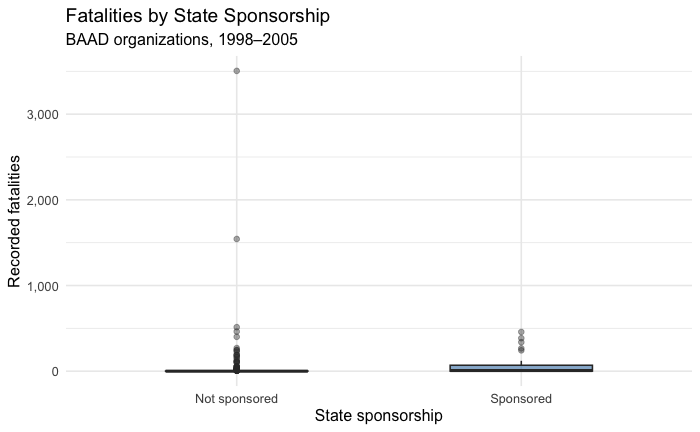

```r
# Figure 1: Fatalities by state sponsorship

figure1_data <- analysis_data %>%
  filter(
    !is.na(sponsored),
    !is.na(fatalities)
  )

# Full distribution on the original fatality scale

figure1 <- ggplot(
  figure1_data,
  aes(
    x = sponsorship_group,
    y = fatalities
  )
) +
  geom_boxplot(
    fill = "steelblue",
    alpha = 0.6,
    outlier.alpha = 0.4,
    width = 0.5
  ) +
  scale_y_continuous(
    labels = scales::label_comma()
  ) +
  labs(
    title = "Fatalities by State Sponsorship",
    subtitle = "BAAD organizations, 1998–2005",
    x = "State sponsorship",
    y = "Recorded fatalities"
  ) +
  theme_minimal(base_size = 12)

print(figure1)

ggsave(
  "outputs/figures/figure1_raw_fatalities.pdf",
  plot = figure1,
  width = 7,
  height = 5
)
```

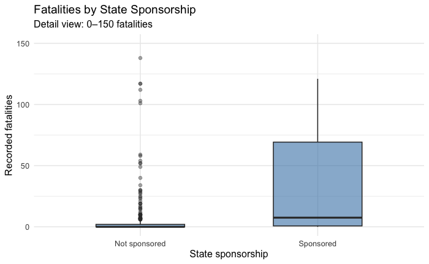

```r
# Zoomed view of the same raw data

figure1_zoom <- figure1 +
  coord_cartesian(ylim = c(0, 150)) +
  labs(
    title = "Fatalities by State Sponsorship",
    subtitle = "Detail view: 0–150 fatalities"
  )

print(figure1_zoom)

ggsave(
  "outputs/figures/figure1_raw_fatalities_zoom.pdf",
  plot = figure1_zoom,
  width = 7,
  height = 5
)
```

Figure 1 compares recorded fatalities between state-sponsored and nonsponsored terrorist organizations during 1998–2005 using the original fatality scale. Both groups exhibit strongly right-skewed distributions, with numerous organizations recording relatively few or no fatalities and a small number accounting for substantially larger counts. Sponsored organizations have a higher median fatality count of 7.5 compared with zero among nonsponsored organizations. However, the largest individual fatality count, 3,505, occurs among nonsponsored organizations. A supplementary zoomed view illustrates differences in the central portions of the distributions without excluding extreme observations from the underlying calculations. These patterns motivate the use of alternative outcome transformations and robustness checks in the subsequent econometric analysis.

## 4.2 Percentage of Organizations Recording Fatalities

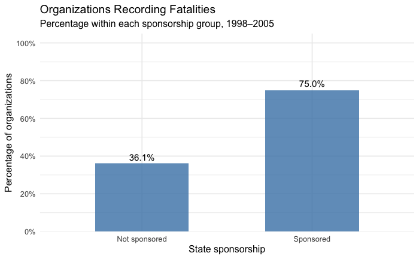

```r
# Figure 2: Percentage of organizations recording fatalities

figure2 <- fatality_incidence %>%
  ggplot(
    aes(
      x = sponsorship_group,
      y = pct_with_fatalities
    )
  ) +
  geom_col(
    fill = "steelblue",
    width = 0.55,
    alpha = 0.8
  ) +
  geom_text(
    aes(
      label = sprintf(
        "%.1f%%",
        pct_with_fatalities
      )
    ),
    vjust = -0.5,
    size = 4
  ) +
  scale_y_continuous(
    limits = c(0, 100),
    breaks = seq(0, 100, 20),
    labels = function(x) paste0(x, "%"),
    expand = expansion(mult = c(0, 0.05))
  ) +
  labs(
    title = "Organizations Recording Fatalities",
    subtitle = "Percentage within each sponsorship group, 1998–2005",
    x = "State sponsorship",
    y = "Percentage of organizations"
  ) +
  theme_minimal(base_size = 12)

print(figure2)

ggsave(
  "outputs/figures/figure2_fatality_incidence.pdf",
  plot = figure2,
  width = 7,
  height = 5
)
```

Figure 2 compares the percentage of state-sponsored and nonsponsored terrorist organizations that recorded at least one fatality during 1998–2005. Among the 32 sponsored organizations, 75.0% recorded fatalities, compared with 36.1% of the 363 nonsponsored organizations. This represents a difference of approximately 38.9 percentage points, indicating that sponsored organizations were substantially more likely to record fatalities during the study period. Unlike Figure 1, which examines the distribution and magnitude of fatalities, this figure focuses on the incidence of any recorded fatalities. The observed difference is descriptive and does not establish a causal relationship between state sponsorship and organizational lethality.

## 4.3 Distribution of Log-Transformed Fatalities

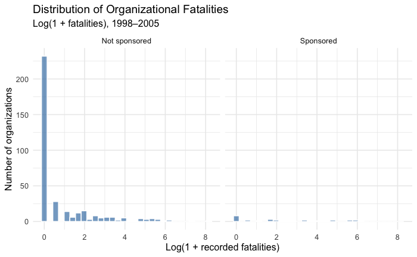

```r
# Figure 3: Distribution of log-transformed fatalities

figure3 <- ggplot(
  analysis_data %>%
    filter(
      !is.na(sponsored),
      !is.na(log_fatalities)
    ),
  aes(
    x = log_fatalities
  )
) +
  geom_histogram(
    bins = 30,
    fill = "steelblue",
    alpha = 0.7,
    color = "white"
  ) +
  facet_wrap(~ sponsorship_group) +
  labs(
    title = "Distribution of Organizational Fatalities",
    subtitle = "Log(1 + fatalities), 1998–2005",
    x = "Log(1 + recorded fatalities)",
    y = "Number of organizations"
  ) +
  theme_minimal(base_size = 12)

print(figure3)

ggsave(
  "outputs/figures/figure3_log_distribution.pdf",
  plot = figure3,
  width = 8,
  height = 5
)
```

The distribution of organizational fatalities was also examined on the log-transformed scale using $\log(1 + \text{fatalities})$. This transformation reduces the influence of extreme outliers and makes the distribution easier to visualize while retaining organizations with zero recorded fatalities. The figure shows that both sponsored and nonsponsored organizations remain concentrated near zero, although the distribution for sponsored organizations appears more shifted away from zero. This pattern is consistent with earlier descriptive results indicating that sponsored organizations were more likely to record fatalities and generally had higher fatality counts. The figure supports the use of the log-transformed outcome in the subsequent regression analysis as a way to reduce skewness while preserving the full sample.

## 4.4 Fatality Incidence by Recorded Support Type

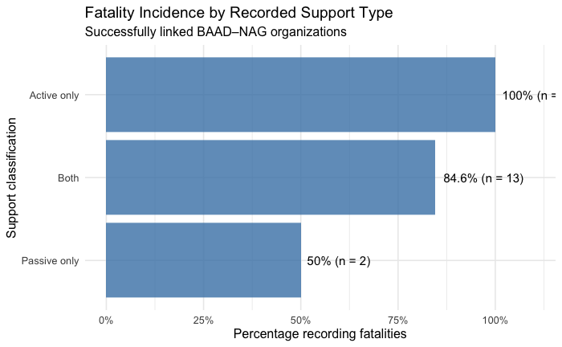

```r
# Prepare support-type figure data

figure4_data <- analysis_data %>%
  filter(
    !is.na(support_type),
    !is.na(fatalities)
  ) %>%
  group_by(support_type) %>%
  summarise(
    groups = n(),
    pct_with_fatalities = 100 * mean(
      fatalities > 0
    ),
    .groups = "drop"
  )

# Figure 4: Fatality incidence by recorded support type

figure4 <- ggplot(
  figure4_data,
  aes(
    x = reorder(
      support_type,
      pct_with_fatalities
    ),
    y = pct_with_fatalities
  )
) +
  geom_col(
    fill = "steelblue",
    alpha = 0.8
  ) +
  geom_text(
    aes(
      label = paste0(
        round(pct_with_fatalities, 1),
        "% (n = ",
        groups,
        ")"
      )
    ),
    hjust = -0.1,
    size = 4
  ) +
  coord_flip() +
  scale_y_continuous(
    limits = c(0, 110),
    breaks = seq(0, 100, 25),
    labels = function(x) paste0(x, "%")
  ) +
  labs(
    title = "Fatality Incidence by Recorded Support Type",
    subtitle = "Successfully linked BAAD–NAG organizations",
    x = "Support classification",
    y = "Percentage recording fatalities"
  ) +
  theme_minimal(base_size = 12)

print(figure4)

ggsave(
  "outputs/figures/figure4_support_type.pdf",
  plot = figure4,
  width = 8,
  height = 5
)
```

Figure 4 summarizes fatality incidence across the 17 organizations successfully linked between BAAD and the NAG dataset, grouped by recorded support type. Organizations receiving both active and de facto support had a fatality incidence rate of 84.6%, while the active-only and passive-only groups recorded rates of 100.0% and 50.0%, respectively. Although these differences are visually notable, the active-only and passive-only categories each contain only two organizations, limiting the reliability of comparisons across support types. Accordingly, this figure is best interpreted as a descriptive supplement to the main sponsorship analysis rather than evidence of differences in causal effects across support classifications.

## 4.5 Organizational Age by State Sponsorship

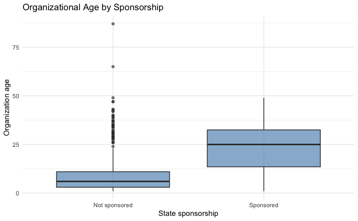

```r
figure5 <- ggplot(
  analysis_data %>%
    filter(
      !is.na(sponsored),
      !is.na(OrgAge)
    ),
  aes(
    x = sponsorship_group,
    y = OrgAge
  )
) +
  geom_boxplot(
    fill = "steelblue",
    alpha = 0.6
  ) +
  labs(
    title = "Organizational Age by Sponsorship",
    x = "State sponsorship",
    y = "Organization age"
  ) +
  theme_minimal()

print(figure5)

ggsave(
  "outputs/figures/figure5_age_distribution.pdf",
  plot = figure5,
  width = 7,
  height = 5
)
```

Figure 5 compares organizational age distributions between state-sponsored and nonsponsored organizations. Sponsored organizations were substantially older, with a median age of 25 years and a mean of 23.84 years, compared with a median of 6 years and a mean of 10.16 years among nonsponsored organizations. Although the nonsponsored group contained several older outliers, its central age distribution was considerably lower. This difference suggests that organizational age may be an important factor associated with both sponsorship status and recorded lethality. Consequently, organizational age is included as a covariate in subsequent regression and matching analyses to account for observable differences between the two groups.

# 5. Regression Analysis and Model Specification

## 5.1 Regression Sample Construction

```r
# Main baseline sample

baseline_data <- analysis_data %>%
  filter(
    complete.cases(
      fatalities,
      sponsored
    )
  )

# Common complete-case sample for adjusted models

regression_data <- analysis_data %>%
  filter(
    complete.cases(
      fatalities,
      sponsored,
      OrgAge,
      ordsize,
      terrStrong,
      degree,
      containrelig,
      containethno
    )
  )

sample_counts <- tibble(
  sample = c(
    "Full BAAD",
    "Baseline regression",
    "Adjusted regression"
  ),

  observations = c(
    nrow(analysis_data),
    nrow(baseline_data),
    nrow(regression_data)
  ),

  sponsored = c(
    sum(analysis_data$sponsored == 1, na.rm = TRUE),
    sum(baseline_data$sponsored == 1),
    sum(regression_data$sponsored == 1)
  )
)

print(sample_counts)
```

```
# A tibble: 3 × 3
  sample              observations sponsored
  <chr>                      <int>     <int>
1 Full BAAD                    395        32
2 Baseline regression          395        32
3 Adjusted regression          395        32
```

```r
write.csv(
  sample_counts,
  "outputs/tables/regression_sample_counts.csv",
  row.names = FALSE
)
```

Two regression samples were constructed to ensure consistent treatment of missing observations across the econometric specifications. The baseline sample required complete information on recorded fatalities and state sponsorship, while the adjusted sample additionally required complete observations for organizational age, size, territorial strength, network degree, and ideological indicators. Both samples retained all 395 BAAD organizations, including 32 sponsored and 363 nonsponsored groups. Consequently, differences in coefficient estimates across the baseline and adjusted regressions cannot be attributed to changes in sample composition caused by missing data. The resulting samples provide a consistent basis for comparing unadjusted and covariate-adjusted associations between state sponsorship and organizational lethality.

## 5.2 Baseline OLS Regression: State Sponsorship and Fatalities

```r
model1 <- lm(
  log_fatalities ~ sponsored,
  data = baseline_data
)

summary(model1)
```

```
Call:
lm(formula = log_fatalities ~ sponsored, data = baseline_data)

Residuals:
    Min      1Q  Median      3Q     Max
-2.5099 -0.8648 -0.8648  0.5215  7.2975

Coefficients:
            Estimate Std. Error t value Pr(>|t|)
(Intercept)  0.86478    0.08278  10.447  < 2e-16 ***
sponsored    1.64507    0.29082   5.657 2.98e-08 ***
---
Signif. codes:  0 ‘***’ 0.001 ‘**’ 0.01 ‘*’ 0.05 ‘.’ 0.1 ‘ ’ 1

Residual standard error: 1.577 on 393 degrees of freedom
Multiple R-squared:  0.07529,   Adjusted R-squared:  0.07294
F-statistic:    32 on 1 and 393 DF,  p-value: 2.977e-08
```

```r
coeftest(
  model1,
  vcov. = vcovHC(
    model1,
    type = "HC3"
  )
)
```

```
t test of coefficients:

            Estimate Std. Error t value  Pr(>|t|)
(Intercept) 0.864780   0.080038 10.8046 < 2.2e-16 ***
sponsored   1.645071   0.387311  4.2474 2.702e-05 ***
---
Signif. codes:  0 ‘***’ 0.001 ‘**’ 0.01 ‘*’ 0.05 ‘.’ 0.1 ‘ ’ 1
```

An initial ordinary least squares regression was estimated to examine the unadjusted association between state sponsorship and organizational lethality, measured as the natural logarithm of one plus recorded fatalities. The estimated sponsorship coefficient was positive (1.6451) and statistically significant using HC3 heteroskedasticity-robust standard errors (SE = 0.3873, p < 0.001). This indicates that sponsored organizations exhibited significantly higher average log-transformed fatalities than nonsponsored organizations before controlling for other characteristics. However, the model explained only 7.53% of the variation in the outcome, and the coefficient cannot be interpreted as causal because potentially important organizational differences remain unaccounted for. Subsequent models introduce additional covariates to assess the robustness of this association.

## 5.3 Adjusted OLS Regression: Organizational Characteristics

```r
# Model 2: OLS with organizational controls

model2 <- lm(
  log_fatalities ~
    sponsored +
    OrgAge +
    factor(ordsize) +
    terrStrong +
    degree,
  data = regression_data
)

# Conventional OLS results

summary(model2)
```

```
Call:
lm(formula = log_fatalities ~ sponsored + OrgAge + factor(ordsize) +
    terrStrong + degree, data = regression_data)

Residuals:
    Min      1Q  Median      3Q     Max
-3.3386 -0.4150 -0.1987  0.4493  4.6950

Coefficients:
                  Estimate Std. Error t value Pr(>|t|)
(Intercept)      0.1956049  0.0926332   2.112 0.035361 *
sponsored        0.2885487  0.2617260   1.102 0.270936
OrgAge           0.0005093  0.0060151   0.085 0.932574
factor(ordsize)1 1.0868554  0.1790889   6.069 3.07e-09 ***
factor(ordsize)2 1.4132407  0.2331416   6.062 3.20e-09 ***
factor(ordsize)3 1.6090999  0.4153908   3.874 0.000126 ***
terrStrong       0.6670995  0.2398350   2.781 0.005676 **
degree           0.2010722  0.0271449   7.407 8.15e-13 ***
---
Signif. codes:  0 ‘***’ 0.001 ‘**’ 0.01 ‘*’ 0.05 ‘.’ 0.1 ‘ ’ 1

Residual standard error: 1.277 on 387 degrees of freedom
Multiple R-squared:  0.4028,    Adjusted R-squared:  0.392
F-statistic: 37.29 on 7 and 387 DF,  p-value: < 2.2e-16
```

```r
# HC3 heteroskedasticity-robust results

model2_robust <- lmtest::coeftest(
  model2,
  vcov. = sandwich::vcovHC(
    model2,
    type = "HC3"
  )
)

print(model2_robust)
```

```
t test of coefficients:

                   Estimate Std. Error t value  Pr(>|t|)
(Intercept)      0.19560494 0.07795550  2.5092   0.01251 *
sponsored        0.28854875 0.35777114  0.8065   0.42044
OrgAge           0.00050925 0.00661616  0.0770   0.93869
factor(ordsize)1 1.08685541 0.22249075  4.8849 1.517e-06 ***
factor(ordsize)2 1.41324070 0.31065293  4.5493 7.215e-06 ***
factor(ordsize)3 1.60909989 0.63780214  2.5229   0.01204 *
terrStrong       0.66709951 0.35898680  1.8583   0.06389 .
degree           0.20107219 0.04556716  4.4127 1.326e-05 ***
---
Signif. codes:  0 ‘***’ 0.001 ‘**’ 0.01 ‘*’ 0.05 ‘.’ 0.1 ‘ ’ 1
```

A second OLS regression was estimated to examine the relationship between state sponsorship and organizational lethality after controlling for organizational age, size, territorial strength, and network degree. The sponsorship coefficient decreased from 1.6451 in the unadjusted model to 0.2885 and was no longer statistically significant (HC3 robust SE = 0.3578, p = 0.420). Organizational size and network degree remained positively and significantly associated with fatalities, while territorial strength and organizational age were not significant at the 5% level. The model explained approximately 40.3% of the variation in log-transformed fatalities. These findings suggest that organizational characteristics account for a substantial portion of the initially observed sponsorship association, although the adjusted relationship cannot be interpreted as causal.

## 5.4 OLS Regression with Organizational Age and Ideological Controls

```r
model3 <- lm(
  log_fatalities ~
    sponsored +
    OrgAge +
    containrelig +
    containethno,
  data = regression_data
)

summary(model3)
```

```
Call:
lm(formula = log_fatalities ~ sponsored + OrgAge + containrelig +
    containethno, data = regression_data)

Residuals:
    Min      1Q  Median      3Q     Max
-3.5064 -0.6133 -0.3019  0.1887  6.3088

Coefficients:
             Estimate Std. Error t value Pr(>|t|)
(Intercept)  0.133183   0.119225   1.117  0.26465
sponsored    0.902912   0.285216   3.166  0.00167 **
OrgAge       0.033747   0.006425   5.252 2.48e-07 ***
containrelig 1.079020   0.166343   6.487 2.66e-10 ***
containethno 0.243931   0.154794   1.576  0.11587
---
Signif. codes:  0 ‘***’ 0.001 ‘**’ 0.01 ‘*’ 0.05 ‘.’ 0.1 ‘ ’ 1

Residual standard error: 1.452 on 390 degrees of freedom
Multiple R-squared:  0.222, Adjusted R-squared:  0.2141
F-statistic: 27.83 on 4 and 390 DF,  p-value: < 2.2e-16
```

```r
coeftest(
  model3,
  vcov. = vcovHC(
    model3,
    type = "HC3"
  )
)
```

```
t test of coefficients:

              Estimate Std. Error t value  Pr(>|t|)
(Intercept)  0.1331827  0.0870248  1.5304   0.12673
sponsored    0.9029119  0.4129742  2.1864   0.02938 *
OrgAge       0.0337471  0.0081887  4.1212 4.607e-05 ***
containrelig 1.0790203  0.2036708  5.2979 1.963e-07 ***
containethno 0.2439312  0.1691994  1.4417   0.15020
---
Signif. codes:  0 ‘***’ 0.001 ‘**’ 0.01 ‘*’ 0.05 ‘.’ 0.1 ‘ ’ 1
```

A third OLS regression was estimated to examine the relationship between state sponsorship and organizational lethality while controlling for organizational age and ideological characteristics. The sponsorship coefficient remained positive and statistically significant (β = 0.9029, HC3 robust SE = 0.4130, p = 0.029). Organizational age and religious ideology were also positively and significantly associated with log-transformed fatalities, while ethnonationalist ideology was not statistically significant. The model explained approximately 22.2% of the variation in fatalities. Compared with the previous specification, these findings suggest that the estimated sponsorship association is sensitive to the inclusion of organizational capacity variables, emphasizing the importance of model specification when interpreting the results.

## 5.5 Fully Adjusted OLS Regression

```r
model4 <- lm(
  log_fatalities ~
    sponsored +
    OrgAge +
    containrelig +
    containethno +
    factor(ordsize) +
    terrStrong +
    degree,
  data = regression_data
)

summary(model4)
```

```
Call:
lm(formula = log_fatalities ~ sponsored + OrgAge + containrelig +
    containethno + factor(ordsize) + terrStrong + degree, data = regression_data)

Residuals:
    Min      1Q  Median      3Q     Max
-3.5258 -0.7241 -0.0231  0.2271  4.1040

Coefficients:
                  Estimate Std. Error t value Pr(>|t|)
(Intercept)      -0.033306   0.101977  -0.327  0.74415
sponsored         0.088965   0.254280   0.350  0.72663
OrgAge            0.006335   0.005895   1.075  0.28323
containrelig      0.810428   0.144460   5.610 3.87e-08 ***
containethno      0.031103   0.133479   0.233  0.81587
factor(ordsize)1  0.908716   0.176362   5.153 4.11e-07 ***
factor(ordsize)2  1.343388   0.228094   5.890 8.44e-09 ***
factor(ordsize)3  1.593882   0.400506   3.980 8.25e-05 ***
terrStrong        0.714759   0.231106   3.093  0.00213 **
degree            0.177521   0.026439   6.714 6.79e-11 ***
---
Signif. codes:  0 ‘***’ 0.001 ‘**’ 0.01 ‘*’ 0.05 ‘.’ 0.1 ‘ ’ 1

Residual standard error: 1.229 on 385 degrees of freedom
Multiple R-squared:  0.4499,    Adjusted R-squared:  0.4371
F-statistic: 34.99 on 9 and 385 DF,  p-value: < 2.2e-16
```

```r
coeftest(
  model4,
  vcov. = vcovHC(
    model4,
    type = "HC3"
  )
)
```

```
t test of coefficients:

                   Estimate Std. Error t value  Pr(>|t|)
(Intercept)      -0.0333056  0.0712053 -0.4677   0.64024
sponsored         0.0889646  0.3604668  0.2468   0.80519
OrgAge            0.0063352  0.0063984  0.9901   0.32274
containrelig      0.8104282  0.1733705  4.6745 4.081e-06 ***
containethno      0.0311031  0.1487921  0.2090   0.83453
factor(ordsize)1  0.9087156  0.2128701  4.2689 2.477e-05 ***
factor(ordsize)2  1.3433883  0.3127449  4.2955 2.210e-05 ***
factor(ordsize)3  1.5938819  0.6586456  2.4199   0.01599 *
terrStrong        0.7147594  0.3505378  2.0390   0.04213 *
degree            0.1775211  0.0409643  4.3336 1.875e-05 ***
---
Signif. codes:  0 ‘***’ 0.001 ‘**’ 0.01 ‘*’ 0.05 ‘.’ 0.1 ‘ ’ 1
```

The final OLS specification incorporated organizational age, ideological characteristics, size, territorial strength, and network degree to examine the association between state sponsorship and organizational lethality after adjustment for all selected covariates. The sponsorship coefficient decreased to 0.0890 and was not statistically significant using HC3 robust standard errors (SE = 0.3605, p = 0.805). In contrast, religious ideology, organizational size, territorial strength, and network degree exhibited positive and statistically significant associations with log-transformed fatalities. The model explained approximately 45.0% of the variation in the outcome. These results indicate that the positive sponsorship association observed in the baseline model is substantially attenuated after accounting for organizational characteristics, although the possibility that some controls are influenced by sponsorship limits causal interpretation.

## 5.6 Consolidated OLS Regression Results and Robust Confidence Intervals

```r
# Create a consistent HC3 regression results table

robust_results <- function(fitted_model, model_name) {

  # Robust variance-covariance matrix
  vcov_matrix <- sandwich::vcovHC(
    fitted_model,
    type = "HC3"
  )

  # Extract coefficients
  estimates <- stats::coef(fitted_model)

  # Extract robust standard errors
  standard_errors <- sqrt(diag(vcov_matrix))

  # Calculate 95% confidence intervals
  critical_value <- qt(
    0.975,
    df = df.residual(fitted_model)
  )

  # Sample size
  sample_size <- nobs(fitted_model)

  # Create results table
  results <- tibble(
    model = model_name,

    term = names(estimates),

    estimate = as.numeric(estimates),

    std_error = as.numeric(
      standard_errors[names(estimates)]
    ),

    ci_lower = estimate -
      critical_value * std_error,

    ci_upper = estimate +
      critical_value * std_error,

    n = sample_size
  )

  return(results)
}

# Combine all four regression models

regression_results <- bind_rows(
  robust_results(model1, "Unadjusted"),
  robust_results(model2, "Original controls"),
  robust_results(model3, "Ideology adjusted"),
  robust_results(model4, "Full controls")
)

# Display results
print(regression_results, n = Inf)
```

```
# A tibble: 25 × 7
   model             term              estimate std_error ci_lower ci_upper     n
   <chr>             <chr>                <dbl>     <dbl>    <dbl>    <dbl> <int>
 1 Unadjusted        (Intercept)       0.865      0.0800   0.707     1.02     395
 2 Unadjusted        sponsored         1.65       0.387    0.884     2.41     395
 3 Original controls (Intercept)       0.196      0.0780   0.0423    0.349    395
 4 Original controls sponsored         0.289      0.358   -0.415     0.992    395
 5 Original controls OrgAge            0.000509   0.00662 -0.0125    0.0135   395
 6 Original controls factor(ordsize)1  1.09       0.222    0.649     1.52     395
 7 Original controls factor(ordsize)2  1.41       0.311    0.802     2.02     395
 8 Original controls factor(ordsize)3  1.61       0.638    0.355     2.86     395
 9 Original controls terrStrong        0.667      0.359   -0.0387    1.37     395
10 Original controls degree            0.201      0.0456   0.111     0.291    395
11 Ideology adjusted (Intercept)       0.133      0.0870  -0.0379    0.304    395
12 Ideology adjusted sponsored         0.903      0.413    0.0910    1.71     395
13 Ideology adjusted OrgAge            0.0337     0.00819  0.0176    0.0498   395
14 Ideology adjusted containrelig      1.08       0.204    0.679     1.48     395
15 Ideology adjusted containethno      0.244      0.169   -0.0887    0.577    395
16 Full controls     (Intercept)      -0.0333     0.0712  -0.173     0.107    395
17 Full controls     sponsored         0.0890     0.360   -0.620     0.798    395
18 Full controls     OrgAge            0.00634    0.00640 -0.00625   0.0189   395
19 Full controls     containrelig      0.810      0.173    0.470     1.15     395
20 Full controls     containethno      0.0311     0.149   -0.261     0.324    395
21 Full controls     factor(ordsize)1  0.909      0.213    0.490     1.33     395
22 Full controls     factor(ordsize)2  1.34       0.313    0.728     1.96     395
23 Full controls     factor(ordsize)3  1.59       0.659    0.299     2.89     395
24 Full controls     terrStrong        0.715      0.351    0.0256    1.40     395
25 Full controls     degree            0.178      0.0410   0.0970    0.258    395
```

```r
# Export results
write.csv(
  regression_results,
  "outputs/tables/regression_results.csv",
  row.names = FALSE
)

# Save models
saveRDS(
  list(
    model1 = model1,
    model2 = model2,
    model3 = model3,
    model4 = model4
  ),
  "outputs/models/ols_models.rds"
)
```

The results from all four OLS specifications were consolidated into a single table using HC3 heteroskedasticity-robust standard errors and 95% confidence intervals. All models retained the same sample of 395 organizations, allowing coefficient differences to be compared without changes in sample composition. State sponsorship was positively and significantly associated with log-transformed fatalities in the unadjusted model and the specification controlling for organizational age and ideology. However, the sponsorship coefficient became smaller and statistically insignificant when organizational size, territorial strength, and network degree were included. In the fully adjusted model, the estimated coefficient was 0.0890, with a 95% confidence interval of approximately −0.620 to 0.798. These results demonstrate that the estimated sponsorship association is sensitive to model specification and suggest that organizational characteristics play an important role in explaining observed differences in lethality. The estimates remain associational rather than causal.

# 6. Matching Analysis

## 6.1 Matching Sample Construction

```r
# Matching uses the complete-case analytical sample

matching_data <- analysis_data %>%
  filter(
    complete.cases(
      fatalities,
      sponsored,
      OrgAge,
      containrelig,
      containethno
    )
  ) %>%
  mutate(
    match_id = row_number()
  )

# Check sponsorship composition

matching_data %>%
  count(sponsored)
```

| sponsored | n |
| --- | --- |
| 0 | 363 |
| 1 | 32 |

```r
# Record sample retention

matching_sample_summary <- tibble(
  full_sample = nrow(analysis_data),

  matching_sample = nrow(matching_data),

  sponsored_available = sum(
    matching_data$sponsored == 1
  ),

  controls_available = sum(
    matching_data$sponsored == 0
  ),

  excluded_observations =
    nrow(analysis_data) - nrow(matching_data)
)

print(matching_sample_summary)
```

```
# A tibble: 1 × 5
  full_sample matching_sample sponsored_available controls_available excluded_observations
        <int>           <int>               <int>              <int>                 <int>
1         395             395                  32                363                     0
```

```r
write.csv(
  matching_sample_summary,
  "outputs/tables/matching_sample_summary.csv",
  row.names = FALSE
)
```

A matching sample was constructed to compare state-sponsored organizations with nonsponsored organizations sharing similar observable characteristics. The sample required complete information on recorded fatalities, sponsorship status, organizational age, religious ideology, and ethnonationalist ideology. All 395 BAAD organizations met these requirements, including 32 sponsored and 363 nonsponsored organizations, resulting in no exclusions due to missing data. Retaining the full sample provides a consistent starting point for the matching analysis, although the number of organizations ultimately matched will depend on the availability of comparable controls. The matching approach is intended to reduce observable differences between sponsorship groups but cannot account for unmeasured confounding.

## 6.2 Propensity Score Matching and Matched Sample Construction

```r
set.seed(4422)

# Nearest-neighbor propensity-score matching
# ATT-oriented, 1:1, without replacement

match_model <- matchit(
  sponsored ~
    OrgAge +
    containrelig +
    containethno,

  data = matching_data,

  method = "nearest",
  distance = "glm",

  estimand = "ATT",

  ratio = 1,
  replace = FALSE,

  caliper = 0.2,
  std.caliper = TRUE
)

# Matching summary

summary(
  match_model,
  standardize = TRUE
)
```

```
Call:
matchit(formula = sponsored ~ OrgAge + containrelig + containethno,
    data = matching_data, method = "nearest", distance = "glm",
    estimand = "ATT", replace = FALSE, caliper = 0.2, std.caliper = TRUE,
    ratio = 1)

Summary of Balance for All Data:
```

|  | Means Treated | Means Control | Std. Mean Diff. | Var. Ratio | eCDF Mean | eCDF Max |
| --- | --- | --- | --- | --- | --- | --- |
| distance | 0.1806 | 0.0722 | 1.0418 | 1.1598 | 0.3790 | 0.6142 |
| OrgAge | 23.8438 | 10.1625 | 1.0539 | 1.2822 | 0.2911 | 0.5692 |
| containrelig | 0.5000 | 0.2755 | 0.4490 | . | 0.2245 | 0.2245 |
| containethno | 0.5312 | 0.3747 | 0.3138 | . | 0.1566 | 0.1566 |

```
Summary of Balance for Matched Data:
```

|  | Means Treated | Means Control | Std. Mean Diff. | Var. Ratio | eCDF Mean | eCDF Max | Std. Pair Dist. |
| --- | --- | --- | --- | --- | --- | --- | --- |
| distance | 0.1751 | 0.1746 | 0.0052 | 0.9752 | 0.0036 | 0.0667 | 0.0239 |
| OrgAge | 23.8000 | 24.7000 | -0.0693 | 1.0620 | 0.0268 | 0.0667 | 0.2799 |
| containrelig | 0.4667 | 0.4333 | 0.0667 | . | 0.0333 | 0.0333 | 0.3333 |
| containethno | 0.5333 | 0.4000 | 0.2672 | . | 0.1333 | 0.1333 | 0.4008 |

```
Sample Sizes:
```

|  | Control | Treated |
| --- | --- | --- |
| All | 363 | 32 |
| Matched | 30 | 30 |
| Unmatched | 333 | 2 |
| Discarded | 0 | 0 |

```r
# Extract matched data

matched_data <- match.data(
  match_model,
  data = matching_data
)

# Ensure the match procedure retained observations

if (nrow(matched_data) == 0) {
  stop(
    "No observations retained after matching. ",
    "Review propensity-score overlap and caliper."
  )
}

matched_data %>%
  count(sponsored)
```

| sponsored | n |
| --- | --- |
| 0 | 30 |
| 1 | 30 |

```r
# Save matched observations

write.csv(
  matched_data,
  "outputs/data/matched_data.csv",
  row.names = FALSE
)

saveRDS(
  match_model,
  "outputs/models/propensity_match_model.rds"
)
```

Propensity score matching was conducted using 1:1 nearest-neighbor matching without replacement and a standardized caliper of 0.2. Propensity scores were estimated using organizational age, religious ideology, and ethnonationalist ideology. The procedure successfully matched 30 of the 32 sponsored organizations with 30 nonsponsored organizations, producing a matched sample of 60 observations. Matching substantially improved covariate balance, particularly for organizational age and religious ideology, with post-matching standardized mean differences below 0.1. However, ethnonationalist ideology retained a standardized mean difference of 0.267, indicating some remaining imbalance. Two sponsored organizations could not be matched within the specified caliper. Consequently, the matched sample provides a more comparable basis for examining differences in organizational lethality, although residual imbalance, unmatched organizations, and unobserved confounding limit causal interpretation.

## 6.3 Matching Retention by Sponsorship Status

```r
# Match retention by treatment group

matching_counts <- matching_data %>%
  group_by(sponsored) %>%
  summarise(
    available = n(),
    .groups = "drop"
  ) %>%
  left_join(
    matched_data %>%
      group_by(sponsored) %>%
      summarise(
        matched = n(),
        .groups = "drop"
      ),
    by = "sponsored"
  ) %>%
  mutate(
    matched = replace_na(matched, 0L),

    unmatched = available - matched,

    pct_retained = 100 *
      matched / available
  )

# Display matching retention

print(matching_counts, width = Inf)
```

```
# A tibble: 2 × 5
  sponsored available matched unmatched pct_retained
      <dbl>     <int>   <int>     <int>        <dbl>
1         0       363      30       333         8.26
2         1        32      30         2        93.8
```

```r
# Export matching retention results

write.csv(
  matching_counts,
  "outputs/tables/matching_counts.csv",
  row.names = FALSE
)
```

The matching procedure retained 30 of the 32 state-sponsored organizations, corresponding to a treatment-group retention rate of 93.75%. These organizations were matched with 30 nonsponsored organizations selected from the 363 available controls, resulting in a control-group retention rate of 8.26%. The relatively low control retention rate reflects the 1:1 matching design, which selects a limited number of comparison organizations rather than retaining the entire nonsponsored sample. Although most sponsored organizations were successfully matched, two remained unmatched within the specified caliper. Consequently, subsequent matched comparisons are based on the 30 retained sponsored organizations and their corresponding controls, limiting the generalizability of the results to all sponsored organizations in the original sample.

## 6.4 Covariate Balance Assessment After Matching

```r
# Covariate balance before and after matching

balance_results <- bal.tab(
  match_model,
  un = TRUE,
  thresholds = c(m = 0.1)
)

print(balance_results)
```

```
Balance Measures
                 Type Diff.Un Diff.Adj        M.Threshold
distance     Distance  1.0418   0.0052     Balanced, <0.1
OrgAge        Contin.  1.0539  -0.0693     Balanced, <0.1
containrelig   Binary  0.2245   0.0333     Balanced, <0.1
containethno   Binary  0.1566   0.1333 Not Balanced, >0.1

Balance tally for mean differences
                   count
Balanced, <0.1         3
Not Balanced, >0.1     1

Variable with the greatest mean difference
     Variable Diff.Adj        M.Threshold
 containethno   0.1333 Not Balanced, >0.1

Sample sizes
          Control Treated
All           363      32
Matched        30      30
Unmatched     333       2
```

```r
# Export the balance table

balance_table <- balance_results$Balance %>%
  as.data.frame() %>%
  tibble::rownames_to_column(
    var = "variable"
  )

write.csv(
  balance_table,
  "outputs/tables/matching_balance.csv",
  row.names = FALSE
)
```

Covariate balance was evaluated before and after propensity score matching using standardized mean differences and a threshold of 0.1. Matching substantially reduced differences between sponsored and nonsponsored organizations in estimated propensity scores, organizational age, and religious ideology, with all three measures falling below the specified threshold. However, ethnonationalist ideology remained imbalanced, with a post-matching standardized mean difference of approximately 0.267. Overall, the matching procedure improved comparability between the treatment and control groups but did not achieve complete balance across all observed characteristics. This remaining imbalance should be considered when interpreting subsequent estimates of the relationship between state sponsorship and organizational lethality.

## 6.5 Visualizing Covariate Balance Before and After Matching

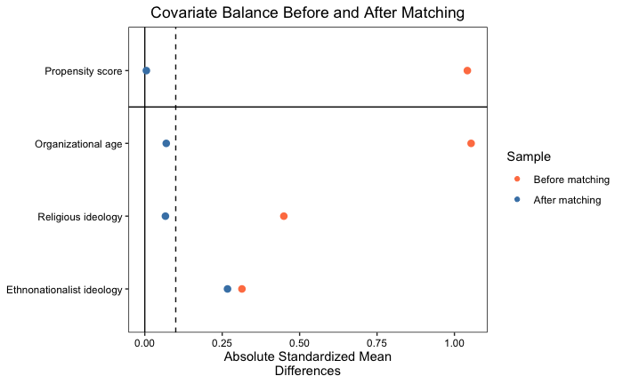

```r
# Figure 6: Standardized mean differences before and after matching

figure6 <- cobalt::love.plot(
  match_model,

  stats = "mean.diffs",

  binary = "std",

  abs = TRUE,

  thresholds = c(m = 0.1),

  sample.names = c(
    "Before matching",
    "After matching"
  ),

  var.names = c(
    distance = "Propensity score",
    OrgAge = "Organizational age",
    containrelig = "Religious ideology",
    containethno = "Ethnonationalist ideology"
  ),

  colors = c("coral", "steelblue"),

  title = "Covariate Balance Before and After Matching"
)

print(figure6)

ggsave(
  "outputs/figures/figure6_matching_balance.pdf",
  plot = figure6,
  width = 8,
  height = 6
)
```

Figure 6 illustrates covariate balance before and after propensity score matching using absolute standardized mean differences. Matching substantially reduced differences between sponsored and nonsponsored organizations in estimated propensity scores, organizational age, and religious ideology, bringing these measures below the 0.1 balance threshold. However, ethnonationalist ideology remained above the threshold, with a post-matching standardized mean difference of approximately 0.267. Although the matching procedure improved overall comparability between the groups, the remaining imbalance indicates that the matched sample does not fully satisfy the selected balance criterion. This limitation should be considered when interpreting subsequent estimates of the relationship between state sponsorship and organizational lethality.

## 6.6 Propensity Score Overlap and Common Support

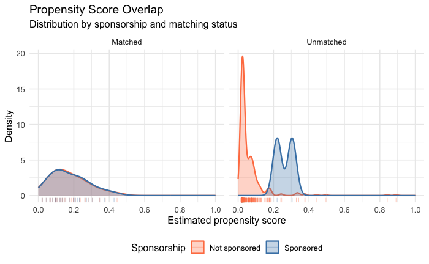

```r
# Figure 7: Propensity score overlap and matching selection

propensity_data <- matching_data %>%
  mutate(
    propensity_score = match_model$distance,

    match_status = if_else(
      match_model$weights > 0,
      "Matched",
      "Unmatched"
    ),

    sponsorship_group = factor(
      sponsored,
      levels = c(0, 1),
      labels = c(
        "Not sponsored",
        "Sponsored"
      )
    )
  )

# Plot propensity score distributions

figure7 <- ggplot(
  propensity_data,
  aes(
    x = propensity_score,
    fill = sponsorship_group,
    color = sponsorship_group
  )
) +
  geom_density(
    alpha = 0.3,
    linewidth = 0.8,
    na.rm = TRUE
  ) +
  geom_rug(
    alpha = 0.25,
    sides = "b"
  ) +
  facet_wrap(
    ~ match_status,
    scales = "fixed"
  ) +
  scale_fill_manual(
    values = c(
      "Not sponsored" = "coral",
      "Sponsored" = "steelblue"
    )
  ) +
  scale_color_manual(
    values = c(
      "Not sponsored" = "coral",
      "Sponsored" = "steelblue"
    )
  ) +
  scale_x_continuous(
    limits = c(0, 1),
    breaks = seq(0, 1, 0.2)
  ) +
  labs(
    title = "Propensity Score Overlap",
    subtitle = "Distribution by sponsorship and matching status",
    x = "Estimated propensity score",
    y = "Density",
    fill = "Sponsorship",
    color = "Sponsorship"
  ) +
  theme_minimal(base_size = 12) +
  theme(
    legend.position = "bottom"
  )

print(figure7)

ggsave(
  "outputs/figures/figure7_propensity_overlap.pdf",
  plot = figure7,
  width = 9,
  height = 5
)
```

Figure 7 illustrates the distribution of estimated propensity scores among matched and unmatched organizations. The unmatched sample contains a large concentration of nonsponsored organizations with relatively low estimated probabilities of receiving state sponsorship, while the matched sample exhibits more comparable propensity score distributions between sponsored and nonsponsored organizations. These patterns suggest that the matching procedure selected control organizations with observable characteristics more similar to those of the sponsored group. Nevertheless, overlap in propensity scores does not establish complete covariate balance, as residual differences in ethnonationalist ideology remain. The matched sample therefore improves comparability but does not eliminate potential confounding or establish a causal relationship between sponsorship and organizational lethality.

## 6.7 Validation of One-to-One Matched Pairs

```r
# Inspect matched-set structure

pair_structure <- matched_data %>%
  group_by(subclass) %>%
  summarise(
    n = n(),
    treated = sum(sponsored == 1),
    controls = sum(sponsored == 0),
    .groups = "drop"
  )

print(pair_structure)
```

```
# A tibble: 30 × 4
   subclass     n treated controls
   <fct>    <int>   <int>    <int>
 1 1            2       1        1
 2 2            2       1        1
 3 3            2       1        1
 4 4            2       1        1
 5 5            2       1        1
 6 6            2       1        1
 7 7            2       1        1
 8 8            2       1        1
 9 9            2       1        1
10 10           2       1        1
# ℹ 20 more rows
# ℹ Use `print(n = ...)` to see more rows
```

```r
# Require complete one-to-one matched sets

stopifnot(
  all(pair_structure$n == 2),
  all(pair_structure$treated == 1),
  all(pair_structure$controls == 1)
)
```

The matched sample was examined to verify the structure of the treatment-control pairs before estimating fatality differences. All 30 matched subclasses contained exactly two organizations, consisting of one state-sponsored organization and one nonsponsored control. This confirmed that the matching procedure produced 30 complete one-to-one pairs, totaling 60 observations. Validating the matched-pair structure ensures that subsequent comparisons can be calculated consistently within each pair, reducing the influence of observed differences in the characteristics used for matching. However, successful pair construction does not guarantee complete covariate balance or eliminate unobserved confounding.

## 6.8 Construction of Matched-Pair Fatality Differences

```r
# One observation per matched pair

matched_pairs <- matched_data %>%
  group_by(subclass) %>%
  summarise(
    treated_id = match_id[sponsored == 1],
    control_id = match_id[sponsored == 0],

    treated_fatalities =
      fatalities[sponsored == 1],

    control_fatalities =
      fatalities[sponsored == 0],

    treated_log =
      log_fatalities[sponsored == 1],

    control_log =
      log_fatalities[sponsored == 0],

    .groups = "drop"
  ) %>%
  mutate(
    fatality_difference =
      treated_fatalities -
      control_fatalities,

    log_difference =
      treated_log -
      control_log
  )

print(
  matched_pairs,
  n = Inf,
  width = Inf
)
```

```
# A tibble: 30 × 9
   subclass treated_id control_id treated_fatalities control_fatalities treated_log control_log
   <fct>         <int>      <int>              <dbl>              <dbl>       <dbl>       <dbl>
 1 1                20         23                107                463       4.68        6.14
 2 2                45        209                  0                270       0           5.60
 3 3               198         70                  0                  0       0           0
 4 4               202        193                  1                  0       0.693       0
 5 5               204        215                458                401       6.13        6.00
 6 6               207        258                  2                 12       1.10        2.56
 7 7               216        217                  8                  4       2.20        1.61
 8 8               228         59                 31                  2       3.47        1.10
 9 9               230        381                 47                  0       3.87        0
10 10              253        234                  0                  0       0           0
11 11              269        266                  4                  1       1.61        0.693
12 12              270         17                  1                  0       0.693       0
```

[output cut: 50 more lines]

```r
write.csv(
  matched_pairs,
  "outputs/data/matched_pairs.csv",
  row.names = FALSE
)
```

A matched-pair dataset was constructed to compare fatalities between each state-sponsored organization and its corresponding nonsponsored control. For all 30 matched pairs, differences were calculated using both raw fatality counts and log-transformed fatalities, with positive values indicating higher fatalities among sponsored organizations. The observed raw differences ranged from −356 to 345 fatalities, demonstrating substantial variation across matched pairs. Some sponsored organizations recorded considerably more fatalities than their controls, while others recorded fewer. These within-pair differences provide the basis for estimating the average matched association between state sponsorship and organizational lethality. However, variation across pairs and the remaining covariate imbalance require cautious interpretation of subsequent estimates.

## 6.9 Verification of the Matched-Pair Dataset

```r
# Rebuild the matched-pairs dataset

matched_pairs <- matched_data %>%
  group_by(subclass) %>%
  summarise(
    treated_id = match_id[sponsored == 1],
    control_id = match_id[sponsored == 0],

    treated_fatalities = fatalities[sponsored == 1],
    control_fatalities = fatalities[sponsored == 0],

    treated_log = log_fatalities[sponsored == 1],
    control_log = log_fatalities[sponsored == 0],

    .groups = "drop"
  ) %>%
  mutate(
    fatality_difference =
      treated_fatalities - control_fatalities,

    log_difference =
      treated_log - control_log
  )

# Verify the result

class(matched_pairs)
```

```
[1] "tbl_df"     "tbl"        "data.frame"
```

```r
str(matched_pairs)
```

```
tibble [30 × 9] (S3: tbl_df/tbl/data.frame)
 $ subclass           : Factor w/ 30 levels "1","2","3","4",..: 1 2 3 4 5 6 7 8 9 10 ...
  ..- attr(*, "names")= chr [1:30] "20" "45" "70" "193" ...
 $ treated_id         : int [1:30] 20 45 198 202 204 207 216 228 230 253 ...
 $ control_id         : int [1:30] 23 209 70 193 215 258 217 59 381 234 ...
 $ treated_fatalities : num [1:30] 107 0 0 1 458 2 8 31 47 0 ...
 $ control_fatalities : num [1:30] 463 270 0 0 401 12 4 2 0 0 ...
 $ treated_log        : num [1:30] 4.682 0 0 0.693 6.129 ...
 $ control_log        : num [1:30] 6.14 5.6 0 0 6 ...
 $ fatality_difference: num [1:30] -356 -270 0 1 57 -10 4 29 47 0 ...
 $ log_difference     : num [1:30] -1.458 -5.602 0 0.693 0.133 ...
```

```r
print(matched_pairs, n = Inf)
```

```
# A tibble: 30 × 9
   subclass treated_id control_id treated_fatalities control_fatalities treated_log control_log
   <fct>         <int>      <int>              <dbl>              <dbl>       <dbl>       <dbl>
 1 1                20         23                107                463       4.68        6.14
 2 2                45        209                  0                270       0           5.60
 3 3               198         70                  0                  0       0           0
 4 4               202        193                  1                  0       0.693       0
 5 5               204        215                458                401       6.13        6.00
 6 6               207        258                  2                 12       1.10        2.56
 7 7               216        217                  8                  4       2.20        1.61
 8 8               228         59                 31                  2       3.47        1.10
 9 9               230        381                 47                  0       3.87        0
10 10              253        234                  0                  0       0           0
11 11              269        266                  4                  1       1.61        0.693
12 12              270         17                  1                  0       0.693       0
```

[output cut: 19 more lines]

```r
# Save matched pairs

write.csv(
  matched_pairs,
  "outputs/data/matched_pairs.csv",
  row.names = FALSE
)
```

## 6.10 Estimation of the Matched Fatality Difference

```r
# Recreate the matched effect on the raw fatality scale

matched_test <- t.test(
  matched_pairs$fatality_difference,
  mu = 0,
  conf.level = 0.95
)

# Calculate statistics

n_pairs <- nrow(matched_pairs)

raw_estimate <- mean(
  matched_pairs$fatality_difference
)

raw_std_error <- sd(
  matched_pairs$fatality_difference
) / sqrt(n_pairs)

# Create results table

matched_effect <- tibble(
  outcome = "Recorded fatalities",

  matched_pairs = n_pairs,

  estimate = raw_estimate,

  std_error = raw_std_error,

  ci_lower = matched_test$conf.int[1],

  ci_upper = matched_test$conf.int[2],

  p_value = matched_test$p.value
)

# Display results

print(matched_effect)
```

```
# A tibble: 1 × 7
  outcome             matched_pairs estimate std_error ci_lower ci_upper p_value
  <chr>                       <int>    <dbl>     <dbl>    <dbl>    <dbl>   <dbl>
1 Recorded fatalities            30     25.7      26.3    -28.1     79.4   0.337
```

```r
# Export results

write.csv(
  matched_effect,
  "outputs/tables/matched_effect.csv",
  row.names = FALSE
)
```

The average matched difference in recorded fatalities was estimated using the 30 treatment-control pairs constructed through propensity score matching. Sponsored organizations recorded an average of 25.7 more fatalities than their matched nonsponsored controls, although this difference was not statistically significant (SE = 26.3, p = 0.337). The 95% confidence interval ranged from −28.1 to 79.4 fatalities, indicating substantial uncertainty surrounding the estimated difference. These findings are consistent with the fully adjusted regression results, which also failed to identify a statistically significant association between state sponsorship and organizational lethality. However, residual covariate imbalance, the limited matched sample, and potential unobserved confounding restrict causal interpretation.

## 6.11 Matched-Pair Analysis of Log-Transformed Fatalities

```r
# Additional matched analysis on the log scale

matched_log_test <- t.test(
  matched_pairs$log_difference,
  mu = 0,
  conf.level = 0.95
)

# Calculate statistics outside tibble

n_pairs <- nrow(matched_pairs)

log_estimate <- mean(
  matched_pairs$log_difference
)

log_std_error <- sd(
  matched_pairs$log_difference
) / sqrt(n_pairs)

# Create results table

matched_log_effect <- tibble(
  outcome = "Log(1 + fatalities)",

  matched_pairs = n_pairs,

  estimate = log_estimate,

  std_error = log_std_error,

  ci_lower = matched_log_test$conf.int[1],

  ci_upper = matched_log_test$conf.int[2],

  p_value = matched_log_test$p.value
)

print(matched_log_effect)
```

```
# A tibble: 1 × 7
  outcome             matched_pairs estimate std_error ci_lower ci_upper p_value
  <chr>                       <int>    <dbl>     <dbl>    <dbl>    <dbl>   <dbl>
1 Log(1 + fatalities)            30    0.886     0.472  -0.0790     1.85  0.0705
```

```r
write.csv(
  matched_log_effect,
  "outputs/tables/matched_log_effect.csv",
  row.names = FALSE
)
```

An additional matched-pair analysis was conducted using log-transformed fatalities to reduce the influence of extreme fatality counts and facilitate comparison with the OLS regression results. The estimated average difference between sponsored organizations and their matched controls was positive (0.886), with a standard error of 0.472 and a 95% confidence interval ranging from −0.079 to 1.85. Although the estimate approached statistical significance at the 10% level (p = 0.071), it was not significant at the conventional 5% threshold. Compared with the matched analysis using raw fatalities, the log-transformed results provided somewhat stronger statistical evidence of a positive association. Nevertheless, the estimates remain sensitive to outcome measurement and are subject to limitations arising from residual covariate imbalance and potential unobserved confounding.

## 6.12 Regression Adjustment Within the Matched Sample

```r
# Regression adjustment within the matched sample

matched_regression <- lm(
  log_fatalities ~
    sponsored +
    OrgAge +
    containrelig +
    containethno,
  data = matched_data,
  weights = weights
)

# Conventional regression results

summary(matched_regression)
```

```
Call:
lm(formula = log_fatalities ~ sponsored + OrgAge + containrelig +
    containethno, data = matched_data, weights = weights)

Residuals:
    Min      1Q  Median      3Q     Max
-3.0802 -1.5963 -0.4874  1.3243  4.2044

Coefficients:
             Estimate Std. Error t value Pr(>|t|)
(Intercept)   1.27593    0.82033   1.555   0.1256
sponsored     0.93213    0.53779   1.733   0.0887 .
OrgAge        0.02127    0.02270   0.937   0.3529
containrelig  0.21830    0.59376   0.368   0.7145
containethno -0.26069    0.54118  -0.482   0.6319
---
Signif. codes:  0 ‘***’ 0.001 ‘**’ 0.01 ‘*’ 0.05 ‘.’ 0.1 ‘ ’ 1

Residual standard error: 2.063 on 55 degrees of freedom
Multiple R-squared:  0.06542,   Adjusted R-squared:  -0.002544
F-statistic: 0.9626 on 4 and 55 DF,  p-value: 0.4354
```

```r
# Cluster-robust covariance matrix by matched pair

matched_cluster_vcov <- sandwich::vcovCL(
  matched_regression,
  cluster = matched_data$subclass,
  type = "HC1"
)

# Cluster-robust inference with 30 matched pairs

matched_regression_robust <- lmtest::coeftest(
  matched_regression,
  vcov. = matched_cluster_vcov,
  df = dplyr::n_distinct(matched_data$subclass) - 1
)

print(matched_regression_robust)
```

```
t test of coefficients:

              Estimate Std. Error t value Pr(>|t|)
(Intercept)   1.275933   0.859606  1.4843  0.14851
sponsored     0.932129   0.499352  1.8667  0.07209 .
OrgAge        0.021272   0.023869  0.8912  0.38017
containrelig  0.218297   0.619890  0.3522  0.72727
containethno -0.260686   0.555468 -0.4693  0.64236
---
Signif. codes:  0 ‘***’ 0.001 ‘**’ 0.01 ‘*’ 0.05 ‘.’ 0.1 ‘ ’ 1
```

```r
# Save fitted model

saveRDS(
  matched_regression,
  "outputs/models/matched_regression.rds"
)
```

A regression-adjusted analysis was conducted within the matched sample of 60 organizations to examine the relationship between state sponsorship and log-transformed fatalities while controlling for organizational age and ideological characteristics. Standard errors were clustered by matched pair to account for dependence between matched observations. The sponsorship coefficient remained positive (0.9321) but was not statistically significant at the 5% level (cluster-robust SE = 0.4994, p = 0.072). Organizational age, religious ideology, and ethnonationalist ideology were also not statistically significant. The model explained approximately 6.5% of the variation in log-transformed fatalities. Although the positive sponsorship coefficient was consistent with the earlier matched-pair analysis, the results provide only suggestive evidence of an association and remain subject to limitations from the small matched sample, residual covariate imbalance, and potential unobserved confounding.

## 6.13 Sensitivity Analysis: Matching on Organizational Capacity

```r
# Secondary matching specification
# Includes potentially post-treatment characteristics

capacity_data <- regression_data %>%
  mutate(match_id = row_number())

set.seed(4422)

capacity_match <- matchit(
  sponsored ~
    OrgAge +
    containrelig +
    containethno +
    factor(ordsize) +
    terrStrong +
    degree,

  data = capacity_data,

  method = "nearest",
  distance = "glm",

  estimand = "ATT",

  ratio = 1,
  replace = FALSE,

  caliper = 0.2,
  std.caliper = TRUE
)

summary(capacity_match, standardize = TRUE)
```

```
Call:
matchit(formula = sponsored ~ OrgAge + containrelig + containethno +
    factor(ordsize) + terrStrong + degree, data = capacity_data,
    method = "nearest", distance = "glm", estimand = "ATT", replace = FALSE,
    caliper = 0.2, std.caliper = TRUE, ratio = 1)

Summary of Balance for All Data:
```

|  | Means Treated | Means Control | Std. Mean Diff. | Var. Ratio | eCDF Mean | eCDF Max |
| --- | --- | --- | --- | --- | --- | --- |
| distance | 0.2816 | 0.0633 | 0.9777 | 4.3936 | 0.4557 | 0.6850 |
| OrgAge | 23.8438 | 10.1625 | 1.0539 | 1.2822 | 0.2911 | 0.5692 |
| containrelig | 0.5000 | 0.2755 | 0.4490 | . | 0.2245 | 0.2245 |
| containethno | 0.5312 | 0.3747 | 0.3138 | . | 0.1566 | 0.1566 |
| `factor(ordsize)`0 | 0.1875 | 0.7025 | -1.3194 | . | 0.5150 | 0.5150 |
| `factor(ordsize)`1 | 0.2812 | 0.1873 | 0.2089 | . | 0.0939 | 0.0939 |
| `factor(ordsize)`2 | 0.3750 | 0.0909 | 0.5868 | . | 0.2841 | 0.2841 |
| `factor(ordsize)`3 | 0.1562 | 0.0193 | 0.3772 | . | 0.1370 | 0.1370 |
| terrStrong | 0.4375 | 0.0799 | 0.7209 | . | 0.3576 | 0.3576 |
| degree | 3.1562 | 1.2314 | 0.6335 | 1.5527 | 0.1440 | 0.3523 |

```
Summary of Balance for Matched Data:
```

|  | Means Treated | Means Control | Std. Mean Diff. | Var. Ratio | eCDF Mean | eCDF Max | Std. Pair Dist. |
| --- | --- | --- | --- | --- | --- | --- | --- |
| distance | 0.2225 | 0.2203 | 0.0099 | 1.0201 | 0.0042 | 0.0769 | 0.0189 |
| OrgAge | 22.1538 | 21.7692 | 0.0296 | 0.7010 | 0.0585 | 0.1923 | 1.0607 |
| containrelig | 0.5000 | 0.4231 | 0.1538 | . | 0.0769 | 0.0769 | 0.7692 |
| containethno | 0.5000 | 0.5769 | -0.1541 | . | 0.0769 | 0.0769 | 0.7707 |
| `factor(ordsize)`0 | 0.2308 | 0.1538 | 0.1971 | . | 0.0769 | 0.0769 | 0.3942 |
| `factor(ordsize)`1 | 0.3462 | 0.3846 | -0.0855 | . | 0.0385 | 0.0385 | 1.1121 |
| `factor(ordsize)`2 | 0.3462 | 0.3846 | -0.0794 | . | 0.0385 | 0.0385 | 1.1917 |
| `factor(ordsize)`3 | 0.0769 | 0.0769 | 0.0000 | . | 0.0000 | 0.0000 | 0.1538 |
| terrStrong | 0.3462 | 0.3462 | 0.0000 | . | 0.0000 | 0.0000 | 0.2308 |
| degree | 3.1154 | 3.0000 | 0.0380 | 0.2338 | 0.0742 | 0.1538 | 1.2531 |

```
Sample Sizes:
```

|  | Control | Treated |
| --- | --- | --- |
| All | 363 | 32 |
| Matched | 26 | 26 |
| Unmatched | 337 | 6 |
| Discarded | 0 | 0 |

```r
capacity_matched <- match.data(
  capacity_match,
  data = capacity_data
)

capacity_matched %>%
  count(sponsored)
```

| sponsored | n |
| --- | --- |
| 0 | 26 |
| 1 | 26 |

```r
saveRDS(
  capacity_match,
  "outputs/models/capacity_match_model.rds"
)
```

A secondary propensity score matching specification was estimated to assess the sensitivity of the results to the inclusion of organizational capacity characteristics. In addition to organizational age and ideological indicators, this specification incorporated organizational size, territorial strength, and network degree. The procedure matched 26 sponsored organizations with 26 nonsponsored controls, retaining 81.25% of the original sponsored sample. Matching substantially improved balance in organizational age, territorial strength, network degree, and estimated propensity scores. However, some imbalance remained in ideological characteristics and the lowest organizational size category. Compared with the primary matching specification, the capacity-adjusted procedure retained fewer sponsored organizations, illustrating a trade-off between incorporating additional matching characteristics and maintaining sample coverage. Because organizational capacity may itself be influenced by state sponsorship, this specification is interpreted as a sensitivity analysis rather than a definitive causal estimate.

## 6.14 Estimation of the Capacity-Adjusted Matched Fatality Difference

```r
# Confirm matched pairs are complete

capacity_structure <- capacity_matched %>%
  group_by(subclass) %>%
  summarise(
    n = n(),
    treated = sum(sponsored == 1),
    controls = sum(sponsored == 0),
    .groups = "drop"
  )

stopifnot(
  nrow(capacity_structure) >= 2,
  all(capacity_structure$n == 2),
  all(capacity_structure$treated == 1),
  all(capacity_structure$controls == 1)
)

capacity_pairs <- capacity_matched %>%
  group_by(subclass) %>%
  summarise(
    treated_fatalities =
      fatalities[sponsored == 1],

    control_fatalities =
      fatalities[sponsored == 0],

    .groups = "drop"
  ) %>%
  mutate(
    difference =
      treated_fatalities -
      control_fatalities
  )

capacity_test <- t.test(
  capacity_pairs$difference
)

capacity_effect <- tibble(
  specification = "Capacity-adjusted matching",

  matched_pairs = nrow(capacity_pairs),

  estimate = mean(
    capacity_pairs$difference
  ),

  ci_lower = capacity_test$conf.int[1],

  ci_upper = capacity_test$conf.int[2],

  p_value = capacity_test$p.value
)

print(capacity_effect)
```

```
# A tibble: 1 × 6
  specification              matched_pairs estimate ci_lower ci_upper p_value
  <chr>                              <int>    <dbl>    <dbl>    <dbl>   <dbl>
1 Capacity-adjusted matching            26    -122.    -407.     162.   0.385
```

```r
write.csv(
  capacity_effect,
  "outputs/tables/capacity_matching_effect.csv",
  row.names = FALSE
)
```

A secondary matched-pair analysis was conducted using organizational capacity variables in addition to age and ideological characteristics. The procedure produced 26 matched pairs, and the estimated average fatality difference was approximately −122, indicating fewer recorded fatalities among sponsored organizations than their matched nonsponsored controls. However, this difference was not statistically significant (p = 0.385), with a wide 95% confidence interval ranging from approximately −407 to 162 fatalities. In contrast to the positive estimate obtained from the primary matching specification, the capacity-adjusted estimate was negative, demonstrating sensitivity to the selection of matching covariates and the resulting matched sample. Because organizational capacity may be influenced by sponsorship and the alternative specification excludes additional treated organizations, these findings should be interpreted as a sensitivity analysis rather than evidence of a negative causal effect.

# 7. Robustness Analysis Using Count Models

## 7.1 Poisson Pseudo-Maximum Likelihood Regression

```r
# PPML with robust standard errors

poisson_model <- glm(
  fatalities ~
    sponsored +
    OrgAge +
    containrelig +
    containethno,

  data = regression_data,

  family = poisson(
    link = "log"
  )
)

summary(poisson_model)
```

```
Call:
glm(formula = fatalities ~ sponsored + OrgAge + containrelig +
    containethno, family = poisson(link = "log"), data = regression_data)

Coefficients:
               Estimate Std. Error z value Pr(>|z|)
(Intercept)   1.9421964  0.0219845  88.344   <2e-16 ***
sponsored     0.2192265  0.0237383   9.235   <2e-16 ***
OrgAge        0.0313981  0.0005539  56.689   <2e-16 ***
containrelig  2.1914745  0.0217051 100.966   <2e-16 ***
containethno -0.3166401  0.0183448 -17.260   <2e-16 ***
---
Signif. codes:  0 ‘***’ 0.001 ‘**’ 0.01 ‘*’ 0.05 ‘.’ 0.1 ‘ ’ 1

(Dispersion parameter for poisson family taken to be 1)

    Null deviance: 69349  on 394  degrees of freedom
Residual deviance: 54352  on 390  degrees of freedom
AIC: 55012

Number of Fisher Scoring iterations: 8
```

```r
# Heteroskedasticity-robust standard errors

poisson_robust <- coeftest(
  poisson_model,

  vcov. = vcovHC(
    poisson_model,
    type = "HC3"
  )
)

print(poisson_robust)
```

```
z test of coefficients:

              Estimate Std. Error z value  Pr(>|z|)
(Intercept)   1.942196   0.310114  6.2629  3.78e-10 ***
sponsored     0.219227   0.606003  0.3618 0.7175329
OrgAge        0.031398   0.017489  1.7953 0.0726001 .
containrelig  2.191475   0.611270  3.5851 0.0003369 ***
containethno -0.316640   0.670973 -0.4719 0.6369899
---
Signif. codes:  0 ‘***’ 0.001 ‘**’ 0.01 ‘*’ 0.05 ‘.’ 0.1 ‘ ’ 1
```

```r
# Exponentiated sponsorship coefficient
# Interpreted as a conditional mean ratio

poisson_ratio <- exp(
  coef(poisson_model)["sponsored"]
)

print(poisson_ratio)
```

```
sponsored
 1.245113
```

```r
saveRDS(
  poisson_model,
  "outputs/models/poisson_model.rds"
)
```

A Poisson pseudo-maximum likelihood regression was estimated as a robustness check using recorded fatalities on their original count scale. The specification controlled for organizational age, religious ideology, and ethnonationalist ideology, with HC3 heteroskedasticity-robust standard errors used for statistical inference. The estimated sponsorship coefficient was positive (0.2192), corresponding to a conditional mean ratio of 1.245, but was not statistically significant (robust SE = 0.6060, p = 0.718). Religious ideology remained positively and significantly associated with fatalities, while organizational age and ethnonationalist ideology were not significant at the 5% level. The substantial difference between conventional and robust standard errors highlights the importance of accounting for variance misspecification in the count outcome. Overall, the PPML results provide no statistically significant evidence of a sponsorship association under this specification, reinforcing the sensitivity of the findings to model choice and outcome measurement.

## 7.2 PPML Coefficient Estimates and Robust Confidence Intervals

```r
poisson_vcov <- vcovHC(
  poisson_model,
  type = "HC3"
)

poisson_estimates <- coef(poisson_model)

poisson_se <- sqrt(
  diag(poisson_vcov)
)

poisson_results <- tibble(
  term = names(poisson_estimates),

  estimate = as.numeric(
    poisson_estimates
  ),

  std_error = as.numeric(
    poisson_se[names(poisson_estimates)]
  ),

  ci_lower = estimate -
    1.96 * std_error,

  ci_upper = estimate +
    1.96 * std_error,

  mean_ratio = exp(estimate),

  ratio_lower = exp(ci_lower),

  ratio_upper = exp(ci_upper)
)

print(poisson_results, n = Inf)
```

```
# A tibble: 5 × 8
  term         estimate std_error ci_lower ci_upper mean_ratio ratio_lower ratio_upper
  <chr>           <dbl>     <dbl>    <dbl>    <dbl>      <dbl>       <dbl>       <dbl>
1 (Intercept)    1.94      0.310   1.33      2.55        6.97        3.80        12.8
2 sponsored      0.219     0.606  -0.969     1.41        1.25        0.380        4.08
3 OrgAge         0.0314    0.0175 -0.00288   0.0657      1.03        0.997        1.07
4 containrelig   2.19      0.611   0.993     3.39        8.95        2.70        29.7
5 containethno  -0.317     0.671  -1.63      0.998       0.729       0.196        2.71
```

```r
write.csv(
  poisson_results,
  "outputs/tables/poisson_results.csv",
  row.names = FALSE
)
```

HC3 heteroskedasticity-robust confidence intervals were calculated for the PPML regression coefficients, and the estimates were exponentiated to express their associations with expected fatality counts as conditional mean ratios. State sponsorship had an estimated mean ratio of 1.245, corresponding to approximately 24.5% higher expected fatalities among sponsored organizations after adjusting for organizational age and ideology. However, the 95% confidence interval ranged from 0.380 to 4.08, indicating that the association was not statistically significant. Religious ideology exhibited a positive and statistically significant association with fatalities, with an estimated mean ratio of 8.95, although its confidence interval was relatively wide. Organizational age and ethnonationalist ideology were not statistically significant at the 5% level. Overall, the findings demonstrate substantial uncertainty surrounding the sponsorship estimate and reinforce the importance of robust statistical inference when analyzing highly dispersed fatality counts.

## 7.3 Outlier Identification and Regression Influence Diagnostics

```r
# Identify organizations with the highest recorded fatalities

highest_fatalities <- analysis_data %>%
  arrange(desc(fatalities)) %>%
  select(
    mastertccode3606,
    group,
    sponsored,
    fatalities,
    OrgAge,
    ordsize,
    terrStrong,
    degree
  ) %>%
  slice_head(n = 15)

# Display highest-fatality organizations

print(
  highest_fatalities,
  n = Inf,
  width = Inf
)
```

```
# A tibble: 15 × 8
   mastertccode3606 group                                               sponsored fatalities OrgAge
              <dbl> <chr>                                                   <dbl>      <dbl>  <dbl>
 1               28 al-Qaeda                                                    0       3505     19
 2            20007 al-Qaeda Organization in the Land of the Two Rivers         0       1543      2
 3             9901 Riyad us-Saliheyn Martyrs' Brigade                          0        514      4
 4             9870 Revolutionary Armed Forces of Colombia (FARC)               0        463     42
 5              278 Lord's Resistance Army (LRA)                                1        458     14
 6               82 Armed Islamic Group                                         0        401     14
 7              200 Hamas                                                       1        385     19
 8             9940 Taliban                                                     1        338     12
 9             9973 UNITA                                                       0        270     40
10               17 al-Fatah                                                    1        266     49
11              144 Dagestan Liberation Army                                    0        248      7
12             9980 United Self-Defense Forces of Colombia (AUC)                0        244      9
```

[output cut: 20 more lines]

```r
# Export highest-fatality table

write.csv(
  highest_fatalities,
  "outputs/tables/highest_fatalities.csv",
  row.names = FALSE
)

# Calculate influence diagnostics for the fully adjusted OLS model

regression_influence <- regression_data %>%
  mutate(
    cooks_distance = cooks.distance(model4)
  ) %>%
  arrange(desc(cooks_distance))

# Calculate conventional Cook's distance screening threshold

cooks_threshold <- 4 / nobs(model4)

# Identify influential observations

influential_observations <- regression_influence %>%
  mutate(
    above_threshold = cooks_distance > cooks_threshold
  ) %>%
  select(
    group,
    sponsored,
    fatalities,
    cooks_distance,
    above_threshold
  ) %>%
  slice_head(n = 15)

# Display influence diagnostics

print(
  influential_observations,
  n = Inf,
  width = Inf
)
```

```
# A tibble: 15 × 5
   group                                               sponsored fatalities cooks_distance
   <chr>                                                   <dbl>      <dbl>          <dbl>
 1 Revolutionary Organization 17 November (RO-N17)             0          1         0.121
 2 Students Islamic Movement of India (SIMI)                   1          0         0.0964
 3 UNITA                                                       0        270         0.0898
 4 Revolutionary Armed Forces of Colombia (FARC)               0        463         0.0601
 5 Moro National Liberation Front (MNLF)                       1          0         0.0587
 6 Mahdi Army                                                  1          0         0.0584
 7 al-Qaeda Organization in the Land of the Two Rivers         0       1543         0.0576
 8 Lord's Resistance Army (LRA)                                1        458         0.0532
 9 Liberation Tigers of Tamil Eelam (LTTE)                     1        243         0.0490
10 al-Qaeda                                                    0       3505         0.0411
11 Free Papua Movement (OPM)                                   1          0         0.0346
12 United Self-Defense Forces of Colombia (AUC)                0        244         0.0329
```

[output cut: 20 more lines]

```r
# Summarize influence screening

influence_summary <- tibble(
  observations = nobs(model4),

  cooks_threshold = cooks_threshold,

  observations_above_threshold = sum(
    regression_influence$cooks_distance > cooks_threshold
  ),

  maximum_cooks_distance = max(
    regression_influence$cooks_distance
  )
)

print(influence_summary, width = Inf)
```

```
# A tibble: 1 × 4
  observations cooks_threshold observations_above_threshold maximum_cooks_distance
         <int>           <dbl>                        <int>                  <dbl>
1          395          0.0101                           50                  0.121
```

```r
# Export influence diagnostics

write.csv(
  regression_influence,
  "outputs/tables/regression_influence.csv",
  row.names = FALSE
)

write.csv(
  influence_summary,
  "outputs/tables/influence_summary.csv",
  row.names = FALSE
)
```

Potential outliers and influential observations were examined to assess the sensitivity of the regression analysis to extreme organizational characteristics and fatality counts. The dataset contained substantial variation in lethality, including organizations with exceptionally high recorded fatalities. Cook’s distance was calculated for the fully adjusted OLS model to identify observations exerting disproportionate influence on the estimated regression coefficients. The results indicated that influential observations were not necessarily those with the highest fatality counts, suggesting that unusual combinations of organizational characteristics may also affect model estimates. These diagnostics provide a basis for subsequent sensitivity testing, although observations should not be excluded solely because they exhibit elevated Cook’s distance values.

## 7.4 Sensitivity Analysis Excluding Extreme Fatality Counts

```r
# Sensitivity to extremely high fatality counts

fatality_cutoff <- quantile(
  regression_data$fatalities,
  probs = 0.99,
  na.rm = TRUE
)

trimmed_data <- regression_data %>%
  filter(fatalities <= fatality_cutoff)

trimmed_model <- lm(
  log_fatalities ~
    sponsored +
    OrgAge +
    containrelig +
    containethno +
    factor(ordsize) +
    terrStrong +
    degree,

  data = trimmed_data
)

coeftest(
  trimmed_model,

  vcov. = vcovHC(
    trimmed_model,
    type = "HC3"
  )
)
```

```
t test of coefficients:

                   Estimate Std. Error t value  Pr(>|t|)
(Intercept)      -0.0158901  0.0723970 -0.2195   0.82639
sponsored         0.2086520  0.3758624  0.5551   0.57913
OrgAge            0.0077333  0.0063226  1.2231   0.22204
containrelig      0.7727358  0.1716754  4.5011 8.993e-06 ***
containethno      0.0170968  0.1499502  0.1140   0.90928
factor(ordsize)1  0.8632845  0.2124204  4.0640 5.860e-05 ***
factor(ordsize)2  1.2447330  0.3020845  4.1205 4.641e-05 ***
factor(ordsize)3  1.3115700  0.6541995  2.0048   0.04569 *
terrStrong        0.7489827  0.3467481  2.1600   0.03139 *
degree            0.1568516  0.0641200  2.4462   0.01489 *
---
Signif. codes:  0 ‘***’ 0.001 ‘**’ 0.01 ‘*’ 0.05 ‘.’ 0.1 ‘ ’ 1
```

```r
trimmed_results <- robust_results(
  trimmed_model,
  "Top 1% excluded"
)

write.csv(
  trimmed_results,
  "outputs/tables/outlier_sensitivity.csv",
  row.names = FALSE
)
```

A sensitivity analysis was conducted to assess whether organizations with exceptionally high fatality counts influenced the fully adjusted OLS results. Observations exceeding the 99th percentile of recorded fatalities were excluded, and the regression was re-estimated using the original set of organizational controls. The sponsorship coefficient increased from 0.0890 in the full sample to 0.2087 in the trimmed sample but remained statistically insignificant using HC3 robust standard errors (SE = 0.3759, p = 0.579). Religious ideology, organizational size, territorial strength, and network degree retained positive and statistically significant associations with log-transformed fatalities. These findings suggest that the lack of a statistically significant sponsorship association in the fully adjusted model is not solely attributable to organizations with extreme fatality counts. Nevertheless, the results remain observational and do not eliminate concerns regarding unmeasured confounding or other influential observations.

## 7.5 Logistic Regression of Fatality Incidence

```r
# Binary-outcome sensitivity analysis

incidence_model <- glm(
  positive_fatalities ~
    sponsored +
    OrgAge +
    containrelig +
    containethno,

  data = regression_data,

  family = binomial(
    link = "logit"
  )
)

summary(incidence_model)
```

```
Call:
glm(formula = positive_fatalities ~ sponsored + OrgAge + containrelig +
    containethno, family = binomial(link = "logit"), data = regression_data)

Coefficients:
             Estimate Std. Error z value Pr(>|z|)
(Intercept)  -1.96618    0.22219  -8.849  < 2e-16 ***
sponsored     0.62653    0.48233   1.299   0.1940
OrgAge        0.06166    0.01133   5.441 5.31e-08 ***
containrelig  1.66885    0.26281   6.350 2.15e-10 ***
containethno  0.59049    0.24155   2.445   0.0145 *
---
Signif. codes:  0 ‘***’ 0.001 ‘**’ 0.01 ‘*’ 0.05 ‘.’ 0.1 ‘ ’ 1

(Dispersion parameter for binomial family taken to be 1)

    Null deviance: 529.15  on 394  degrees of freedom
Residual deviance: 426.94  on 390  degrees of freedom
AIC: 436.94

Number of Fisher Scoring iterations: 4
```

```r
coeftest(
  incidence_model,

  vcov. = vcovHC(
    incidence_model,
    type = "HC3"
  )
)
```

```
z test of coefficients:

              Estimate Std. Error z value  Pr(>|z|)
(Intercept)  -1.966184   0.219602 -8.9534 < 2.2e-16 ***
sponsored     0.626529   0.592224  1.0579   0.29009
OrgAge        0.061663   0.012697  4.8566 1.194e-06 ***
containrelig  1.668851   0.278492  5.9925 2.067e-09 ***
containethno  0.590494   0.249648  2.3653   0.01802 *
---
Signif. codes:  0 ‘***’ 0.001 ‘**’ 0.01 ‘*’ 0.05 ‘.’ 0.1 ‘ ’ 1
```

```r
# Average model-predicted probability by
# setting sponsorship to each condition

predict_0 <- regression_data %>%
  mutate(sponsored = 0)

predict_1 <- regression_data %>%
  mutate(sponsored = 1)

probability_comparison <- tibble(
  sponsorship = c(
    "Not sponsored",
    "Sponsored"
  ),

  average_predicted_probability = c(
    mean(
      predict(
        incidence_model,
        newdata = predict_0,
        type = "response"
      )
    ),

    mean(
      predict(
        incidence_model,
        newdata = predict_1,
        type = "response"
      )
    )
  )
)

print(probability_comparison)
```

```
# A tibble: 2 × 2
  sponsorship   average_predicted_probability
  <chr>                                 <dbl>
1 Not sponsored                         0.383
2 Sponsored                             0.503
```

```r
write.csv(
  probability_comparison,
  "outputs/tables/incidence_model_probabilities.csv",
  row.names = FALSE
)
```

A logistic regression was estimated as an additional robustness check to examine whether state sponsorship was associated with the likelihood of an organization recording at least one fatality. The model controlled for organizational age, religious ideology, and ethnonationalist ideology, with HC3 robust standard errors used for inference. The sponsorship coefficient was positive (0.6265) but not statistically significant (SE = 0.5922, p = 0.290). Organizational age and both ideological indicators exhibited positive and statistically significant associations with fatality incidence. The average model-predicted probability of recording fatalities was 38.3% under the nonsponsored condition and 50.3% under the sponsored condition, representing an estimated difference of approximately 12 percentage points. However, the lack of statistical significance for the sponsorship coefficient indicates insufficient evidence of an adjusted association in this specification. These results further demonstrate that the estimated relationship between state sponsorship and organizational lethality depends on the outcome measure and model specification.

## 7.6 Comparison of Primary and Capacity-Adjusted Matching Estimates

```r
# Compare matching results on the raw fatality scale

matching_comparison <- dplyr::bind_rows(
  matched_effect %>%
    transmute(
      specification = "Age and ideology matching",
      matched_pairs,
      estimate,
      ci_lower,
      ci_upper,
      p_value
    ),

  capacity_effect %>%
    select(
      specification,
      matched_pairs,
      estimate,
      ci_lower,
      ci_upper,
      p_value
    )
)

# Display comparison as a regular tibble

print(
  matching_comparison,
  n = Inf,
  width = Inf
)
```

```
# A tibble: 2 × 6
  specification              matched_pairs estimate ci_lower ci_upper p_value
  <chr>                              <int>    <dbl>    <dbl>    <dbl>   <dbl>
1 Age and ideology matching             30     25.7    -28.1     79.4   0.337
2 Capacity-adjusted matching            26   -122.    -407.     162.    0.385
```

```r
# Export matching comparison

write.csv(
  matching_comparison,
  "outputs/tables/matching_comparison.csv",
  row.names = FALSE
)
```

The primary and capacity-adjusted matching estimates were compared to evaluate the sensitivity of the estimated sponsorship association to the selection of matching variables. The primary specification, matching on organizational age and ideology, produced an average difference of 25.67 additional fatalities among sponsored organizations, although the estimate was not statistically significant (p = 0.337). In contrast, the capacity-adjusted specification produced a negative average difference of 122.23 fatalities, which was also statistically insignificant (p = 0.385). Both confidence intervals included zero, indicating substantial uncertainty regarding the direction and magnitude of the association. The reversal in the estimated coefficient demonstrates sensitivity to matching specification and sample composition. Because organizational capacity may be influenced by state sponsorship, the secondary specification is interpreted as a robustness check rather than a definitive causal estimate.

## 7.7 Visualization of Matching Sensitivity Estimates

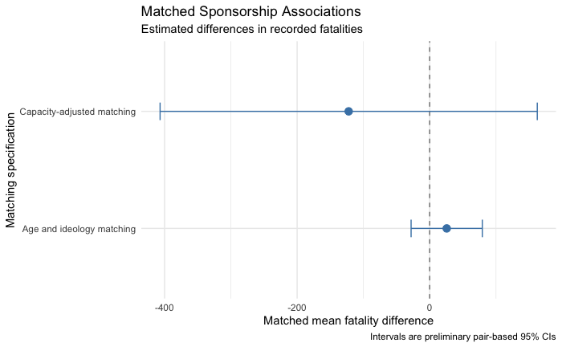

```r
figure8 <- ggplot(
  matching_comparison,
  aes(
    x = estimate,
    y = specification
  )
) +
  geom_vline(
    xintercept = 0,
    linetype = "dashed",
    color = "gray50"
  ) +
  geom_point(
    size = 3,
    color = "steelblue"
  ) +
  geom_errorbarh(
    aes(
      xmin = ci_lower,
      xmax = ci_upper
    ),
    height = 0.15,
    color = "steelblue"
  ) +
  labs(
    title = "Matched Sponsorship Associations",
    subtitle = "Estimated differences in recorded fatalities",
    x = "Matched mean fatality difference",
    y = "Matching specification",
    caption = "Intervals are preliminary pair-based 95% CIs"
  ) +
  theme_minimal()

print(figure8)

ggsave(
  "outputs/figures/figure8_matching_estimates.pdf",
  plot = figure8,
  width = 8,
  height = 5
)
```

Figure 8 compares the estimated differences in recorded fatalities between sponsored organizations and matched nonsponsored controls under the two propensity score matching specifications. The primary specification produced a positive average difference of 25.67 fatalities, while the capacity-adjusted specification produced a negative difference of 122.23 fatalities. However, the 95% confidence intervals for both estimates included zero, indicating that neither association was statistically significant at the 5% level. The substantial difference between the point estimates highlights the sensitivity of the matching results to covariate selection and changes in matched sample composition. Because organizational capacity may be influenced by sponsorship, and residual confounding remains possible, these results should be interpreted as evidence of methodological sensitivity rather than definitive causal effects.

## 7.8 Visualization of Sponsorship Coefficients Across OLS Specifications

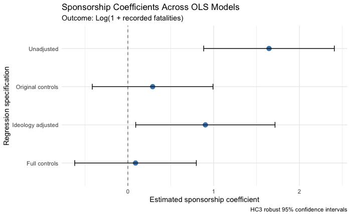

```r
# Compare the sponsorship coefficient across
# log-OLS regression specifications

regression_sponsorship <- regression_results %>%
  filter(term == "sponsored")

figure9 <- ggplot(
  regression_sponsorship,
  aes(
    x = estimate,
    y = model
  )
) +
  geom_vline(
    xintercept = 0,
    linetype = "dashed",
    color = "gray50"
  ) +
  geom_point(
    size = 3,
    color = "steelblue"
  ) +
  geom_errorbar(
    aes(
      xmin = ci_lower,
      xmax = ci_upper
    ),
    orientation = "y",
    width = 0.15
  ) +
  labs(
    title = "Sponsorship Coefficients Across OLS Models",
    subtitle = "Outcome: Log(1 + recorded fatalities)",
    x = "Estimated sponsorship coefficient",
    y = "Regression specification",
    caption = "HC3 robust 95% confidence intervals"
  ) +
  theme_minimal()

print(figure9)

ggsave(
  "outputs/figures/figure9_regression_estimates.pdf",
  plot = figure9,
  width = 8,
  height = 5
)
```

This figure summarizes how the estimated sponsorship coefficient changes across the four OLS specifications using log-transformed fatalities as the outcome. The unadjusted model shows the largest positive association between sponsorship and fatalities, while the coefficient becomes much smaller once organizational controls are added. In the ideology-adjusted model the sponsorship coefficient remains positive and statistically significant, but in the fully controlled model it becomes very small and is no longer statistically distinguishable from zero. Overall, the figure shows that the estimated sponsorship association is sensitive to model specification, especially to the inclusion of organizational capacity and network-related controls.

# 8. Final Analysis Summary and Reproducibility

## 8.1 Exporting Final Analytical Data and Session Information

```r
# Final organization-level analytical dataset

write.csv(
  analysis_data,
  "outputs/data/analysis_data_final.csv",
  row.names = FALSE
)

saveRDS(
  analysis_data,
  "outputs/data/analysis_data_final.rds"
)

# Final sample and matching models

saveRDS(
  list(
    baseline_data = baseline_data,
    regression_data = regression_data,
    matching_data = matching_data,
    matched_data = matched_data,
    matched_pairs = matched_pairs,
    capacity_matched = capacity_matched
  ),
  "outputs/data/analysis_samples.rds"
)

# Save the complete analysis session information

capture.output(
  sessionInfo(),
  file = "outputs/session_info.txt"
)
```

## 8.2 Summary of Principal Findings

```r
cat("\n")
```

```r
cat("====================================\n")
cat("ECO 4422 ECONOMETRICS PROJECT\n")
```

```
ECO 4422 ECONOMETRICS PROJECT
```

```r
cat("FINAL ANALYSIS SUMMARY\n")
```

```
FINAL ANALYSIS SUMMARY
```

```r
cat("====================================\n\n")
cat(
  "Total BAAD organizations:",
  nrow(analysis_data),
  "\n"
)
```

```
Total BAAD organizations: 395
```

```r
cat(
  "Sponsored organizations:",
  sum(
    analysis_data$sponsored == 1,
    na.rm = TRUE
  ),
  "\n"
)
```

```
Sponsored organizations: 32
```

```r
cat(
  "Verified BAAD-NAG matches:",
  nrow(verified_matches),
  "\n"
)
```

```
Verified BAAD-NAG matches: 17
```

```r
cat(
  "Unmatched sponsored BAAD organizations:",
  nrow(still_unmatched),
  "\n\n"
)
```

```
Unmatched sponsored BAAD organizations: 15
```

```r
cat("Fatality incidence by sponsorship:\n")
```

```
Fatality incidence by sponsorship:
```

```r
print(fatality_incidence)
```

```
# A tibble: 2 × 6
  sponsorship_group total_groups groups_with_fatalities groups_without_fatali…¹ pct_with_fatalities
  <fct>                    <int>                  <int>                   <int>               <dbl>
1 Not sponsored              363                    131                     232                36.1
2 Sponsored                   32                     24                       8                75
# ℹ abbreviated name: ¹groups_without_fatalities
# ℹ 1 more variable: pct_without_fatalities <dbl>
```

```r
cat("\nRegression sample sizes:\n")
```

```
Regression sample sizes:
```

```r
print(sample_counts)
```

```
# A tibble: 3 × 3
  sample              observations sponsored
  <chr>                      <int>     <int>
1 Full BAAD                    395        32
2 Baseline regression          395        32
3 Adjusted regression          395        32
```

```r
cat("\nMatching retention:\n")
```

```
Matching retention:
```

```r
print(matching_counts)
```

```
# A tibble: 2 × 5
  sponsored available matched unmatched pct_retained
      <dbl>     <int>   <int>     <int>        <dbl>
1         0       363      30       333         8.26
2         1        32      30         2        93.8
```

```r
cat("\nMatching balance:\n")
```

```
Matching balance:
```

```r
print(balance_results)
```

```
Balance Measures
                 Type Diff.Un Diff.Adj        M.Threshold
distance     Distance  1.0418   0.0052     Balanced, <0.1
OrgAge        Contin.  1.0539  -0.0693     Balanced, <0.1
containrelig   Binary  0.2245   0.0333     Balanced, <0.1
containethno   Binary  0.1566   0.1333 Not Balanced, >0.1

Balance tally for mean differences
                   count
Balanced, <0.1         3
Not Balanced, >0.1     1

Variable with the greatest mean difference
     Variable Diff.Adj        M.Threshold
 containethno   0.1333 Not Balanced, >0.1

Sample sizes
          Control Treated
All           363      32
Matched        30      30
Unmatched     333       2
```

```r
cat("\nMatched fatality difference:\n")
```

```
Matched fatality difference:
```

```r
print(matched_effect)
```

```
# A tibble: 1 × 7
  outcome             matched_pairs estimate std_error ci_lower ci_upper p_value
  <chr>                       <int>    <dbl>     <dbl>    <dbl>    <dbl>   <dbl>
1 Recorded fatalities            30     25.7      26.3    -28.1     79.4   0.337
```

```r
cat("\nCapacity-adjusted matching:\n")
```

```
Capacity-adjusted matching:
```

```r
print(capacity_effect)
```

```
# A tibble: 1 × 6
  specification              matched_pairs estimate ci_lower ci_upper p_value
  <chr>                              <int>    <dbl>    <dbl>    <dbl>   <dbl>
1 Capacity-adjusted matching            26    -122.    -407.     162.   0.385
```

```r
cat("\nRegression sponsorship coefficients:\n")
```

```
Regression sponsorship coefficients:
```

```r
print(regression_sponsorship)
```

```
# A tibble: 4 × 7
  model             term      estimate std_error ci_lower ci_upper     n
  <chr>             <chr>        <dbl>     <dbl>    <dbl>    <dbl> <int>
1 Unadjusted        sponsored   1.65       0.387   0.884     2.41    395
2 Original controls sponsored   0.289      0.358  -0.415     0.992   395
3 Ideology adjusted sponsored   0.903      0.413   0.0910    1.71    395
4 Full controls     sponsored   0.0890     0.360  -0.620     0.798   395
```

```r
cat("\nPPML sponsorship mean ratio:\n")
```

```
PPML sponsorship mean ratio:
```

```r
print(poisson_ratio)
```

```
sponsored
 1.245113
```

```r
cat("\n")
```

```r
cat("====================================\n")
cat("ANALYSIS OUTPUTS SAVED\n")
```

```
ANALYSIS OUTPUTS SAVED
```

```r
cat("====================================\n")
```

The final analytical dataset, regression models, matching samples, and supporting outputs were preserved to support reproducibility and verification of the econometric analysis. The study included 395 terrorist organizations, of which 32 were classified as state-sponsored. Descriptive results indicated that sponsored organizations recorded fatalities more frequently and exhibited higher average lethality than nonsponsored organizations. However, the initially significant sponsorship association weakened substantially after adjustment for organizational characteristics. Propensity score matching, Poisson regression, and logistic regression analyses generally produced statistically insignificant sponsorship estimates, while alternative matching specifications demonstrated sensitivity to covariate selection and sample composition. Overall, the findings suggest that observable organizational characteristics play an important role in explaining differences in terrorist organization lethality, although limitations related to observational data, residual imbalance, potential post-treatment controls, and unobserved confounding prevent definitive causal conclusions.